# EWAS senescence

Dan Evans

17 September 2021

# 1 EWAS introduction

DNA methylation quantity is expressed as $\beta$

$$\beta = M/(M + U)$$

Where M = hybridization signal from a methylated version of a cytosine nucleotide and U = hybridization signal from an unmethylated version of a cytosine nucleotide. Beta can be interpreted as the proportion of methylation signal for a probe, and values range from 0 to 1. Beta is easy to interpret for humans, but typically has a bimodal distribution that is suboptimal for statistical modeling. Thus, we analyze M-values, which are another way to express methylation values for probes.

$$M-value = log_2(M/U)$$

EPIC array has type 1 and type 2 probes. Type 1 probes are from the old 27K array that uses 2 bead types per CpG. The type I probes are labeled I-green and I-red. The newer type 2 probes uses one bead type. Most of the EPIC array probes are type II.

A detection probability represents the probability of a detected signal being background flourescence. If the probability is high, the signal is more likely to be background, and the value should be set to missing.

Standard workflows suggest to remove data points with detection P-value > 0.05.

# 2 Sesame package processing of Illumina EPIC array

## 2.1 Sesame package intro

- EWAS array Illumina EPIC 850
- Sesame is a [bioconductor package](https://www.bioconductor.org/packages/release/bioc/html/sesame.html)
  - Improvements on previous EWAS packages for low-level processing.
  - Existing methods do not identify artifacts associated with detection failure. Sources of failure include: insufficient DNA due to germline or somatic deletions or hyperpolymorphism, probe cross-hybridization.
  - Probes are masked (set to NA) with two methods: P-value with out-of-band array hybridization (pOOBAH) so that probes with detection p-value > 0.05 are masked. Probes with design issues such as overlapping SNPs are masked. Minfi uses negative control probes for background, but there are only 411 of them on the EPIC array. Sesame pOOBAH uses out-of-band (OOB) signals from type I probes in addition to negative control probes to improve background subtraction and detection calling. Minfi adopted pOOBAH, but false positive rate higher than Sesame’s implementation (Fig 2 Zhou 2018, NAR).
  - Non-linear dye bias correction. Minfi uses linear scaling. Sesame uses nonlinear scaling to better fit dye bias.

```r
knitr::opts_chunk$set(cache.lazy = FALSE)
```

## 2.2 Sesame installation on UCR cluster

Installation of sesame and dependencies went fine, no errors or warnings.

```r
if (!requireNamespace("BiocManager", quietly = TRUE))
    install.packages("BiocManager")

BiocManager::install("sesame", lib = "~/Rlibs")
```

Installed sesameData as a dependency.

Can check version of loaded packages with sessionInfo()

Sesame version 1.6 used.

## 2.3 Load libraries

This includes libraries for Sesame and Minfi.

```r
library(tidyverse)
library(readxl)
library(knitr)
library(sesame)
library(wheatmap)
library(multtest)
library(limma)
library(RColorBrewer)
library(kableExtra)
library(missMethyl)
#library(IlluminaHumanMethylationEPICmanifest)
#library(IlluminaHumanMethylationEPICanno.ilm10b4.hg19)
```

Set global variables.

```r
dir_out <- "../results/"
```

## 2.4 Mask and normalize data and create eset

Sesame pipeline involves probe masking with pOOBAH, normalization with noob, and nonlinear dye bias correction.

Noob = background subtraction based on normal-exponential deconvolution using out-of-band probes.

The pipeline can be thought of as adding pOOBAH to noob. Then also the non-linear dye bias correction should be better than minfi’s linear correction.

```r
IDATprefixes <- searchIDATprefixes(dir.name = "../data/raw/idatFiles/")
t1 <- Sys.time()
betas <- openSesame(IDATprefixes)
Sys.time() - t1
```

```
## Time difference of 8.869421 mins
```

```r
#Warnings issued. These are also shown in minfi vignette, so they are expected.
#50: In readChar(con, nchars = n) : truncating string with embedded nuls

#Convert Betas to Mvalues. Check if there are beta values that will result in infinite results.
sum(is.na(betas))
```

```
## [1] 4462814
```

```r
sum(is.na(betas))/length(betas)
```

```
## [1] 0.1610579
```

```r
sum(betas==0 & !is.na(betas))
```

```
## [1] 0
```

```r
sum(betas==1 & !is.na(betas))
```

```
## [1] 0
```

```r
sum(betas<0 & !is.na(betas))
```

```
## [1] 0
```

```r
sum(betas>1 & !is.na(betas))
```

```
## [1] 0
```

```r
Mvals <- BetaValueToMValue(betas)

#column names for betas and Mvals is currently the Basename. Rename it to sampleID to make it easier to understand.
sampsheet <- read_csv("../data/raw/idatFiles/SampleSheet.csv")
#Are there true discrepancies between ExternalSampleID, SampleLabel, and Description?
#row 2 ExternalSampleID shows "+P" but SampleLabel shows "-P" and Description shows "no pyruvate". Many discrepancies like that. I ended up trusting SampleLabel and Description, but is that wrong?
cbind(sampsheet$ExternalSampleID, sampsheet$SampleLabel, sampsheet$Description)
```

```
##       [,1]       [,2]       [,3]
##  [1,] "C -P 1"   "C -P 1"   "Non-senescent mtDNA-containing controls no pyruvate"
##  [2,] "C +P 1"   "C -P 2"   "Non-senescent mtDNA-containing controls no pyruvate"
##  [3,] "mtD -P 1" "C -P 3"   "Non-senescent mtDNA-containing controls no pyruvate"
##  [4,] "mtD +P 1" "C -P 4"   "Non-senescent mtDNA-containing controls no pyruvate"
##  [5,] "C -P 2"   "C -P 5"   "Non-senescent mtDNA-containing controls no pyruvate"
##  [6,] "C +P 2"   "C -P 6"   "Non-senescent mtDNA-containing controls no pyruvate"
##  [7,] "mtD -P 2" "C +P 1"   "Non-senescent mtDNA-containing controls with pyruvate"
##  [8,] "mtD +P 2" "C +P 2"   "Non-senescent mtDNA-containing controls with pyruvate"
##  [9,] "C -P 3"   "C +P 3"   "Non-senescent mtDNA-containing controls with pyruvate"
## [10,] "C +P 3"   "C +P 4"   "Non-senescent mtDNA-containing controls with pyruvate"
## [11,] "mtD -P 3" "C +P 5"   "Non-senescent mtDNA-containing controls with pyruvate"
## [12,] "mtD +P 3" "C +P 6"   "Non-senescent mtDNA-containing controls with pyruvate"
## [13,] "C -P 4"   "mtD -P 1" "Senescent mtDNA-depleted cells no pyruvate"
## [14,] "C +P 4"   "mtD -P 2" "Senescent mtDNA-depleted cells no pyruvate"
```

[output cut: 18 more lines]

```r
sum(colnames(betas) != sampsheet$Basename) #not in same order
```

```
## [1] 16
```

```r
cbind(colnames(betas),sampsheet$Basename) #visually show not in same order
```

```
##       [,1]                  [,2]
##  [1,] "203833040074_R01C01" "203839170002_R01C01"
##  [2,] "203833040074_R02C01" "203839170002_R02C01"
##  [3,] "203833040074_R03C01" "203839170002_R03C01"
##  [4,] "203833040074_R04C01" "203839170002_R04C01"
##  [5,] "203833040074_R05C01" "203839170002_R05C01"
##  [6,] "203833040074_R06C01" "203839170002_R06C01"
##  [7,] "203833040074_R07C01" "203839170002_R07C01"
##  [8,] "203833040074_R08C01" "203839170002_R08C01"
##  [9,] "203836210101_R01C01" "203836210101_R01C01"
## [10,] "203836210101_R02C01" "203836210101_R02C01"
## [11,] "203836210101_R03C01" "203836210101_R03C01"
## [12,] "203836210101_R04C01" "203836210101_R04C01"
## [13,] "203836210101_R05C01" "203836210101_R05C01"
## [14,] "203836210101_R06C01" "203836210101_R06C01"
```

[output cut: 18 more lines]

```r
cbind(colnames(betas),sampsheet$Basename[match(sampsheet$Basename, colnames(betas))])#now in correct order
```

```
##       [,1]                  [,2]
##  [1,] "203833040074_R01C01" "203833040074_R01C01"
##  [2,] "203833040074_R02C01" "203833040074_R02C01"
##  [3,] "203833040074_R03C01" "203833040074_R03C01"
##  [4,] "203833040074_R04C01" "203833040074_R04C01"
##  [5,] "203833040074_R05C01" "203833040074_R05C01"
##  [6,] "203833040074_R06C01" "203833040074_R06C01"
##  [7,] "203833040074_R07C01" "203833040074_R07C01"
##  [8,] "203833040074_R08C01" "203833040074_R08C01"
##  [9,] "203836210101_R01C01" "203836210101_R01C01"
## [10,] "203836210101_R02C01" "203836210101_R02C01"
## [11,] "203836210101_R03C01" "203836210101_R03C01"
## [12,] "203836210101_R04C01" "203836210101_R04C01"
## [13,] "203836210101_R05C01" "203836210101_R05C01"
## [14,] "203836210101_R06C01" "203836210101_R06C01"
```

[output cut: 18 more lines]

```r
#reorder sampsheet to match sample order in data matrix
sampsheet <- sampsheet[match(sampsheet$Basename, colnames(betas)),]
sampsheet <- dplyr::rename(sampsheet, sampleID = ExternalSampleID)
cbind(sampsheet$sampleID, sampsheet$SampleLabel, sampsheet$Description)
```

```
##       [,1]       [,2]       [,3]
##  [1,] "- ATV 1"  "- ATV"    "Non-senescent DMSO-treated control cells"
##  [2,] "+ ATV 1"  "- ATV"    "Non-senescent DMSO-treated control cells"
##  [3,] "- ATV 2"  "- ATV"    "Non-senescent DMSO-treated control cells"
##  [4,] "+ ATV 2"  "- ATV"    "Non-senescent DMSO-treated control cells"
##  [5,] "- ATV 3"  "+ ATV"    "Senescent ATV-treated cells"
##  [6,] "+ ATV 3"  "+ ATV"    "Senescent ATV-treated cells"
##  [7,] "- ATV 4"  "+ ATV"    "Senescent ATV-treated cells"
##  [8,] "+ ATV 4"  "+ ATV"    "Senescent ATV-treated cells"
##  [9,] "C -P 3"   "C +P 3"   "Non-senescent mtDNA-containing controls with pyruvate"
## [10,] "C +P 3"   "C +P 4"   "Non-senescent mtDNA-containing controls with pyruvate"
## [11,] "mtD -P 3" "C +P 5"   "Non-senescent mtDNA-containing controls with pyruvate"
## [12,] "mtD +P 3" "C +P 6"   "Non-senescent mtDNA-containing controls with pyruvate"
## [13,] "C -P 4"   "mtD -P 1" "Senescent mtDNA-depleted cells no pyruvate"
## [14,] "C +P 4"   "mtD -P 2" "Senescent mtDNA-depleted cells no pyruvate"
```

[output cut: 18 more lines]

```r
sampsheet$sampleID[1:8] <- paste0("ATV", 1:8)
sampsheet$sampleID[9:32] <- paste0("midas", 1:24)
cbind(sampsheet$sampleID, sampsheet$SampleLabel, sampsheet$Description)
```

```
##       [,1]      [,2]       [,3]
##  [1,] "ATV1"    "- ATV"    "Non-senescent DMSO-treated control cells"
##  [2,] "ATV2"    "- ATV"    "Non-senescent DMSO-treated control cells"
##  [3,] "ATV3"    "- ATV"    "Non-senescent DMSO-treated control cells"
##  [4,] "ATV4"    "- ATV"    "Non-senescent DMSO-treated control cells"
##  [5,] "ATV5"    "+ ATV"    "Senescent ATV-treated cells"
##  [6,] "ATV6"    "+ ATV"    "Senescent ATV-treated cells"
##  [7,] "ATV7"    "+ ATV"    "Senescent ATV-treated cells"
##  [8,] "ATV8"    "+ ATV"    "Senescent ATV-treated cells"
##  [9,] "midas1"  "C +P 3"   "Non-senescent mtDNA-containing controls with pyruvate"
## [10,] "midas2"  "C +P 4"   "Non-senescent mtDNA-containing controls with pyruvate"
## [11,] "midas3"  "C +P 5"   "Non-senescent mtDNA-containing controls with pyruvate"
## [12,] "midas4"  "C +P 6"   "Non-senescent mtDNA-containing controls with pyruvate"
## [13,] "midas5"  "mtD -P 1" "Senescent mtDNA-depleted cells no pyruvate"
## [14,] "midas6"  "mtD -P 2" "Senescent mtDNA-depleted cells no pyruvate"
```

[output cut: 18 more lines]

```r
translate_trt <- function(ch){
  switch(ch,
     "Non-senescent DMSO-treated control cells" = "noSen_ATV",
     "Non-senescent mtDNA-containing controls no pyruvate" = "noSen_Mt_noPy",
     "Non-senescent mtDNA-containing controls with pyruvate" = "noSen_Mt_Py",
     "Non-senescent mtDNA-depleted controls cells with pyruvate" = "noSen_noMt_Py",
     "Senescent ATV-treated cells" = "sen_ATV",
     "Senescent mtDNA-depleted cells no pyruvate" = "sen_noMt_noPy"
     )
}

sampsheet <- sampsheet %>%
    mutate(treatment = map_chr(Description, translate_trt)) %>%
    mutate(treatment = factor(treatment))

cbind(sampsheet$sampleID, sampsheet$SampleLabel, sampsheet$Description, as.character(sampsheet$treatment))
```

```
##       [,1]      [,2]       [,3]                                                        [,4]
##  [1,] "ATV1"    "- ATV"    "Non-senescent DMSO-treated control cells"                  "noSen_ATV"
##  [2,] "ATV2"    "- ATV"    "Non-senescent DMSO-treated control cells"                  "noSen_ATV"
##  [3,] "ATV3"    "- ATV"    "Non-senescent DMSO-treated control cells"                  "noSen_ATV"
##  [4,] "ATV4"    "- ATV"    "Non-senescent DMSO-treated control cells"                  "noSen_ATV"
##  [5,] "ATV5"    "+ ATV"    "Senescent ATV-treated cells"                               "sen_ATV"
##  [6,] "ATV6"    "+ ATV"    "Senescent ATV-treated cells"                               "sen_ATV"
##  [7,] "ATV7"    "+ ATV"    "Senescent ATV-treated cells"                               "sen_ATV"
##  [8,] "ATV8"    "+ ATV"    "Senescent ATV-treated cells"                               "sen_ATV"
##  [9,] "midas1"  "C +P 3"   "Non-senescent mtDNA-containing controls with pyruvate"     "noSen_Mt_Py"
## [10,] "midas2"  "C +P 4"   "Non-senescent mtDNA-containing controls with pyruvate"     "noSen_Mt_Py"
## [11,] "midas3"  "C +P 5"   "Non-senescent mtDNA-containing controls with pyruvate"     "noSen_Mt_Py"
## [12,] "midas4"  "C +P 6"   "Non-senescent mtDNA-containing controls with pyruvate"     "noSen_Mt_Py"
## [13,] "midas5"  "mtD -P 1" "Senescent mtDNA-depleted cells no pyruvate"                "sen_noMt_noPy"
## [14,] "midas6"  "mtD -P 2" "Senescent mtDNA-depleted cells no pyruvate"                "sen_noMt_noPy"
```

[output cut: 18 more lines]

```r
colnames(betas) <- sampsheet$sampleID
colnames(Mvals) <- sampsheet$sampleID
row.names(sampsheet) <- sampsheet$sampleID

#Probe annotation
dat_fData <- read_tsv("~/bigdata/EWAStools/arrayAnnotation/EPIC.hg19.manifest.tsv")
length(rownames(betas)) == length(dat_fData$probeID)
```

```
## [1] TRUE
```

```r
sum(rownames(betas) != dat_fData$probeID)
```

```
## [1] 865915
```

```r
#Reorder annotation to match betas
dat_fData <- dat_fData[match(rownames(betas), dat_fData$probeID),]
sum(rownames(betas) != dat_fData$probeID)
```

```
## [1] 0
```

```r
head(dat_fData$probeID)
```

```
## [1] "cg00000029" "cg00000103" "cg00000109" "cg00000155" "cg00000158" "cg00000165"
```

```r
head(rownames(betas))
```

```
## [1] "cg00000029" "cg00000103" "cg00000109" "cg00000155" "cg00000158" "cg00000165"
```

```r
row.names(dat_fData) <- dat_fData$probeID

eset_betas <- ExpressionSet(assayData = betas,
                phenoData = AnnotatedDataFrame(sampsheet),
                featureData = AnnotatedDataFrame(dat_fData)
                )

write_rds(eset_betas, file = "../data/formatted/eset_betas_MS.rds")

eset_Mvals <- ExpressionSet(assayData = Mvals,
                phenoData = AnnotatedDataFrame(sampsheet),
                featureData = AnnotatedDataFrame(dat_fData)
                )

write_rds(eset_Mvals, file = "../data/formatted/eset_Mvals_MS.rds")
```

## 2.5 QC on IDATs

The sesame pipeline above already produced cleaned data. This chunk goes backwards and examines QC of the raw data again.

Read in idats as sigsets, apply QC.

The Sigset data structure is an S4 class with 6 slots. Using lapply with readIDATpair creates a list of Sigset objects. Each list element is a Sigset for each sample. To plot or anything across samples, you’ll need to apply a function across the list.

```r
pdat <- pData(eset_Mvals)
IDATprefixes <- searchIDATprefixes(dir.name = "../data/raw/idatFiles/")
ssets <- lapply(IDATprefixes, readIDATpair)
qc10 <- do.call(rbind, lapply(ssets, function(x) as.data.frame(sesameQC(x))))
#add sample names
sum(names(ssets) != pdat$Basename)
cbind(names(ssets), pdat$Basename)
qc10 <- qc10 %>%
    mutate(sample_name = pdat$SampleLabel) %>%
    mutate(sample_desc = pdat$Description) %>%
    dplyr::select(sample_name, sample_desc, everything())

#frac_na_cg = percentage of cg probes with NA
#mean_intensity = for type II probes. Low intensity typically bad quality
#mean_beta_cg = mean beta cg probes
#frac_meth_cg = percentage cg probes with beta > 0.7
#frac_unmeth_cg = percentage cg probes with beta < 0.3
#GCT = residual incomplete bisulfite conversion. Closer to one = more complete conversion.
qcvars <- c("sample_name", "sample_desc", "num_probes_cg", "num_na_cg", "frac_na_cg", "mean_intensity", "mean_beta_cg", "frac_meth_cg", "frac_unmeth_cg", "sex", "age", "ethnicity", "GCT")
qc10 %>%
    dplyr::select(any_of(qcvars)) %>%
    kable
```

## 2.6 Missing analysis of masked Betas

The fraction of NAs are signs of masking due to variety of reasons including failed detection, high background, putative low quality probes etc.

Now we move back to the QCed betas generated from the first step.

First, remove failed samples and probes. How many samples are missing across all probes? How many probes are missing across all samples?

Also, create chip variable to be used later.

```r
#eset_betas <- read_rds("../data/formatted/eset_betas_MS.rds")
eset_Mvals <- read_rds("../data/formatted/eset_Mvals_MS.rds")
dim(eset_Mvals) #865,918 probes
```

```
## Features  Samples
##   865918       32
```

```r
e <- exprs(eset_Mvals)
pdat <- pData(eset_Mvals)
miss_sample <- apply(e, 2, function(x) sum(is.na(x))/length(x) )
miss_probe_blank <- apply(e, 1, function(x) sum(is.na(x))/length(x) )
length(miss_sample)
```

```
## [1] 32
```

```r
length(miss_probe_blank)
```

```
## [1] 865918
```

```r
sum(miss_sample >= 0.95) #0 samples have missing rate greater than 95%
```

```
## [1] 0
```

```r
#no samples that are essentially blanks.
#show missingness for all samples
data.frame(sampleID = names(miss_sample), treatment = pdat$treatment, miss_sample = miss_sample, stringsAsFactors = F) %>%
  kable()
```

|  | sampleID | treatment | miss_sample |
| --- | --- | --- | --- |
| ATV1 | ATV1 | noSen_ATV | 0.1653240 |
| ATV2 | ATV2 | noSen_ATV | 0.1699641 |
| ATV3 | ATV3 | noSen_ATV | 0.1611273 |
| ATV4 | ATV4 | noSen_ATV | 0.1712310 |
| ATV5 | ATV5 | sen_ATV | 0.1833418 |
| ATV6 | ATV6 | sen_ATV | 0.1653228 |
| ATV7 | ATV7 | sen_ATV | 0.1704168 |
| ATV8 | ATV8 | sen_ATV | 0.1674177 |
| midas1 | midas1 | noSen_Mt_Py | 0.1760120 |
| midas2 | midas2 | noSen_Mt_Py | 0.1584596 |
| midas3 | midas3 | noSen_Mt_Py | 0.1565876 |
| midas4 | midas4 | noSen_Mt_Py | 0.1530457 |
| midas5 | midas5 | sen_noMt_noPy | 0.1764867 |
| midas6 | midas6 | sen_noMt_noPy | 0.1570611 |
| midas7 | midas7 | sen_noMt_noPy | 0.1586074 |
| midas8 | midas8 | sen_noMt_noPy | 0.1596098 |
| midas9 | midas9 | sen_noMt_noPy | 0.1638769 |
| midas10 | midas10 | sen_noMt_noPy | 0.1636991 |
| midas11 | midas11 | noSen_noMt_Py | 0.1491850 |
| midas12 | midas12 | noSen_noMt_Py | 0.1437215 |
| midas13 | midas13 | noSen_noMt_Py | 0.1555979 |
| midas14 | midas14 | noSen_noMt_Py | 0.1443035 |
| midas15 | midas15 | noSen_noMt_Py | 0.1459977 |
| midas16 | midas16 | noSen_noMt_Py | 0.1480683 |
| midas17 | midas17 | noSen_Mt_noPy | 0.1689594 |
| midas18 | midas18 | noSen_Mt_noPy | 0.1670193 |
| midas19 | midas19 | noSen_Mt_noPy | 0.1613236 |
| midas20 | midas20 | noSen_Mt_noPy | 0.1510028 |
| midas21 | midas21 | noSen_Mt_noPy | 0.1666925 |
| midas22 | midas22 | noSen_Mt_noPy | 0.1564282 |
| midas23 | midas23 | noSen_Mt_Py | 0.1601918 |
| midas24 | midas24 | noSen_Mt_Py | 0.1577701 |

```r
sum(miss_probe_blank >= 1) #119,631 completely missing probes. Many are masked by design.
```

```
## [1] 119631
```

```r
sum(miss_probe_blank >= 0.95) #121,925 Remove these, then determine number of samples with missing rate>0.05.
```

```
## [1] 121925
```

```r
#keep probes with < 0.95 missingness
eset_Mvals_clean <- eset_Mvals[miss_probe_blank < 0.95,]
dim(eset_Mvals_clean) #743,993 probes
```

```
## Features  Samples
##   743993       32
```

```r
#eset_betas_clean <- eset_betas[miss_probe_blank < 0.95,]
#dim(eset_betas_clean)

#After removing failed probes, estimate sample missing rate.
e <- exprs(eset_Mvals_clean)
miss_sample <- apply(e, 2, function(x) sum(is.na(x))/length(x) )
miss_probe <- apply(e, 1, function(x) sum(is.na(x))/length(x) )

data.frame(sampleID = names(miss_sample), treatment = pdat$treatment, miss_sample = miss_sample, stringsAsFactors = F) %>%
    arrange(desc(miss_sample)) %>%
    kable()
```

|  | sampleID | treatment | miss_sample |
| --- | --- | --- | --- |
| ATV5 | ATV5 | sen_ATV | 0.0495099 |
| midas5 | midas5 | sen_noMt_noPy | 0.0415300 |
| midas1 | midas1 | noSen_Mt_Py | 0.0409843 |
| ATV4 | ATV4 | noSen_ATV | 0.0354264 |
| ATV7 | ATV7 | sen_ATV | 0.0344788 |
| ATV2 | ATV2 | noSen_ATV | 0.0339506 |
| midas17 | midas17 | noSen_Mt_noPy | 0.0327732 |
| ATV8 | ATV8 | sen_ATV | 0.0310030 |
| midas18 | midas18 | noSen_Mt_noPy | 0.0305164 |
| midas21 | midas21 | noSen_Mt_noPy | 0.0301347 |
| ATV1 | ATV1 | noSen_ATV | 0.0285849 |
| ATV6 | ATV6 | sen_ATV | 0.0285540 |
| midas9 | midas9 | sen_noMt_noPy | 0.0268739 |
| midas10 | midas10 | sen_noMt_noPy | 0.0266669 |
| midas19 | midas19 | noSen_Mt_noPy | 0.0238873 |
| ATV3 | ATV3 | noSen_ATV | 0.0237166 |
| midas23 | midas23 | noSen_Mt_Py | 0.0225714 |
| midas8 | midas8 | sen_noMt_noPy | 0.0219034 |
| midas7 | midas7 | sen_noMt_noPy | 0.0207341 |
| midas2 | midas2 | noSen_Mt_Py | 0.0205997 |
| midas24 | midas24 | noSen_Mt_Py | 0.0197663 |
| midas6 | midas6 | sen_noMt_noPy | 0.0189814 |
| midas3 | midas3 | noSen_Mt_Py | 0.0184061 |
| midas22 | midas22 | noSen_Mt_noPy | 0.0181991 |
| midas13 | midas13 | noSen_noMt_Py | 0.0172475 |
| midas4 | midas4 | noSen_Mt_Py | 0.0143026 |
| midas20 | midas20 | noSen_Mt_noPy | 0.0119504 |
| midas11 | midas11 | noSen_noMt_Py | 0.0098737 |
| midas16 | midas16 | noSen_noMt_Py | 0.0086627 |
| midas15 | midas15 | noSen_noMt_Py | 0.0064073 |
| midas14 | midas14 | noSen_noMt_Py | 0.0048025 |
| midas12 | midas12 | noSen_noMt_Py | 0.0044113 |

```r
#After removing failed probes, estimate probe missing rate

sum(miss_probe == 0) #692,879 probes with no missings
```

```
## [1] 692879
```

```r
sum(miss_probe > 0) #51,114 probes with missings in at least one sample
```

```
## [1] 51114
```

```r
miss_probe_f <- cut(miss_probe, breaks = seq(0, 1, 0.05))
table(miss_probe_f)
```

```
## miss_probe_f
##   (0,0.05] (0.05,0.1] (0.1,0.15] (0.15,0.2] (0.2,0.25] (0.25,0.3] (0.3,0.35] (0.35,0.4] (0.4,0.45] (0.45,0.5] (0.5,0.55] (0.55,0.6] (0.6,0.65] (0.65,0.7] (0.7,0.75] (0.75,0.8] (0.8,0.85] (0.85,0.9] (0.9,0.95]   (0.95,1]
##       8857       7700       2575       4087       3856       1495       2505       1094       1992       1883        910       1794        895       1845       1880       1030       2349       1323       3044          0
```

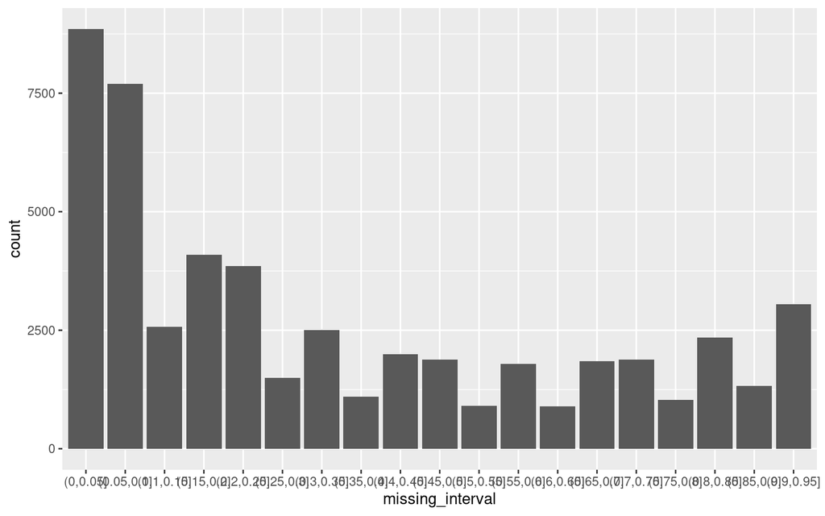

```r
data.frame(missing_interval = miss_probe_f) %>%
    filter(!is.na(missing_interval)) %>%
    ggplot(aes(missing_interval)) +
    geom_bar()
```

```r
#Keep probes with missing rate <= 5%
eset_Mvals_clean <- eset_Mvals_clean[miss_probe <= 0.05,]
dim(eset_Mvals_clean) #701,736 probes
```

```
## Features  Samples
##   701736       32
```

```r
#Create chip variable
p1 <- pData(eset_Mvals_clean)
table(str_remove(p1$Basename, pattern = "_.*$"))
```

```
##
## 203833040074 203836210101 203839170001 203839170002
##            8            8            8            8
```

```r
p1 <- p1 %>%
    mutate(chip = as.factor(str_remove(Basename, pattern = "_.*$")))
table(p1$chip)
```

```
##
## 203833040074 203836210101 203839170001 203839170002
##            8            8            8            8
```

```r
pData(eset_Mvals_clean) <- p1
write_rds(eset_Mvals_clean, file = "../data/formatted/eset_Mvals_MS_clean.rds")
```

# 3 Data distributions

## 3.1 Distributions

Summary of sample IDs and descriptions

```r
eset_Mvals_clean <- read_rds("../data/formatted/eset_Mvals_MS_clean.rds")
p1 <- pData(eset_Mvals_clean)
p1 %>%
    dplyr::select(sampleID, Description) %>%
    kable()
```

| sampleID | Description |
| --- | --- |
| ATV1 | Non-senescent DMSO-treated control cells |
| ATV2 | Non-senescent DMSO-treated control cells |
| ATV3 | Non-senescent DMSO-treated control cells |
| ATV4 | Non-senescent DMSO-treated control cells |
| ATV5 | Senescent ATV-treated cells |
| ATV6 | Senescent ATV-treated cells |
| ATV7 | Senescent ATV-treated cells |
| ATV8 | Senescent ATV-treated cells |
| midas1 | Non-senescent mtDNA-containing controls with pyruvate |
| midas2 | Non-senescent mtDNA-containing controls with pyruvate |
| midas3 | Non-senescent mtDNA-containing controls with pyruvate |
| midas4 | Non-senescent mtDNA-containing controls with pyruvate |
| midas5 | Senescent mtDNA-depleted cells no pyruvate |
| midas6 | Senescent mtDNA-depleted cells no pyruvate |
| midas7 | Senescent mtDNA-depleted cells no pyruvate |
| midas8 | Senescent mtDNA-depleted cells no pyruvate |
| midas9 | Senescent mtDNA-depleted cells no pyruvate |
| midas10 | Senescent mtDNA-depleted cells no pyruvate |
| midas11 | Non-senescent mtDNA-depleted controls cells with pyruvate |
| midas12 | Non-senescent mtDNA-depleted controls cells with pyruvate |
| midas13 | Non-senescent mtDNA-depleted controls cells with pyruvate |
| midas14 | Non-senescent mtDNA-depleted controls cells with pyruvate |
| midas15 | Non-senescent mtDNA-depleted controls cells with pyruvate |
| midas16 | Non-senescent mtDNA-depleted controls cells with pyruvate |
| midas17 | Non-senescent mtDNA-containing controls no pyruvate |
| midas18 | Non-senescent mtDNA-containing controls no pyruvate |
| midas19 | Non-senescent mtDNA-containing controls no pyruvate |
| midas20 | Non-senescent mtDNA-containing controls no pyruvate |
| midas21 | Non-senescent mtDNA-containing controls no pyruvate |
| midas22 | Non-senescent mtDNA-containing controls no pyruvate |
| midas23 | Non-senescent mtDNA-containing controls with pyruvate |
| midas24 | Non-senescent mtDNA-containing controls with pyruvate |

## 3.2 Boxplots of M-values

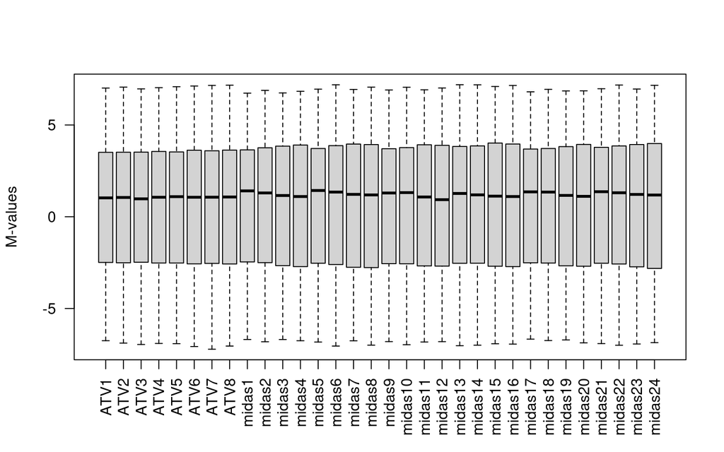

```r
eset_Mvals_clean <- read_rds("../data/formatted/eset_Mvals_MS_clean.rds")
boxplot(exprs(eset_Mvals_clean), las = 2, ylab = "M-values")
abline(h = median(exprs(eset_Mvals_clean)), col = "blue")
```

## 3.3 Density plot sample groups

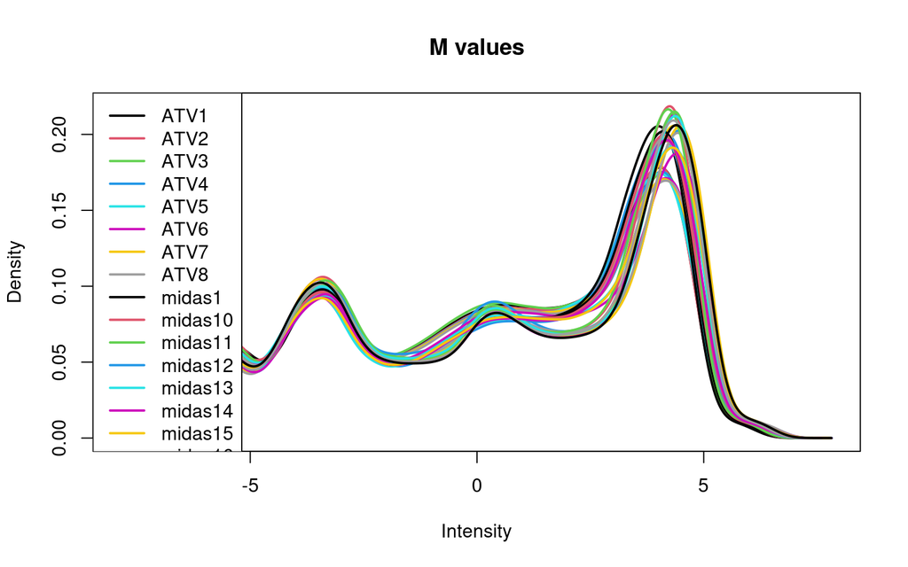

```r
eset_Mvals_clean <- read_rds("../data/formatted/eset_Mvals_MS_clean.rds")
p1 <- pData(eset_Mvals_clean) %>%
    dplyr::select(sampleID, SampleLabel, Description, treatment) %>%
    kable()

#eset_Mvals_sub <- eset_Mvals_clean[,which(p1$treatment == "sen_ATV" | p1$treatment == "noSen_ATV")]
plotDensities(eset_Mvals_clean, main = "M values", legend = TRUE)
```

# 4 Cluster analysis

Using MDS and PCA

## 4.1 MDS all samples with chip labels

Multidimensional scaling using probes with most variance. Not the same as PCA. Should be similar, but not the same.

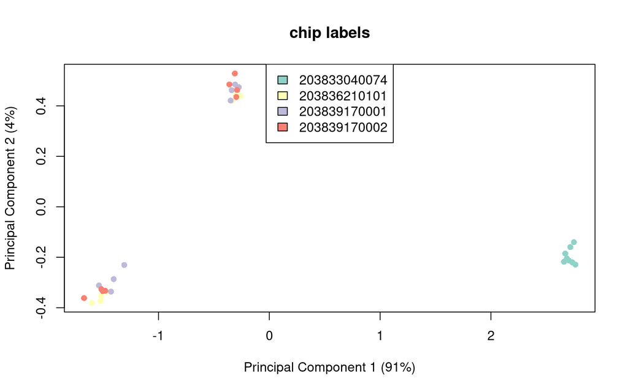

```r
plot_MDS <- function(mylabel, myeset){
    group <- pData(myeset)[[mylabel]]
    col.group <- group
    levels(col.group) <- brewer.pal(nlevels(col.group), "Set3")
    col.group.ch <- as.character(col.group)
    plotMDS(myeset, col = col.group.ch, gene.selection = "common",
        main = paste(mylabel, "labels"), pch = 16)
    legend("top", fill = levels(col.group), legend = levels(group))
}

eset_Mvals_clean <- read_rds("../data/formatted/eset_Mvals_MS_clean.rds")

plot_MDS(mylabel = "chip", myeset = eset_Mvals_clean)
```

## 4.2 MDS all samples with treatment labels

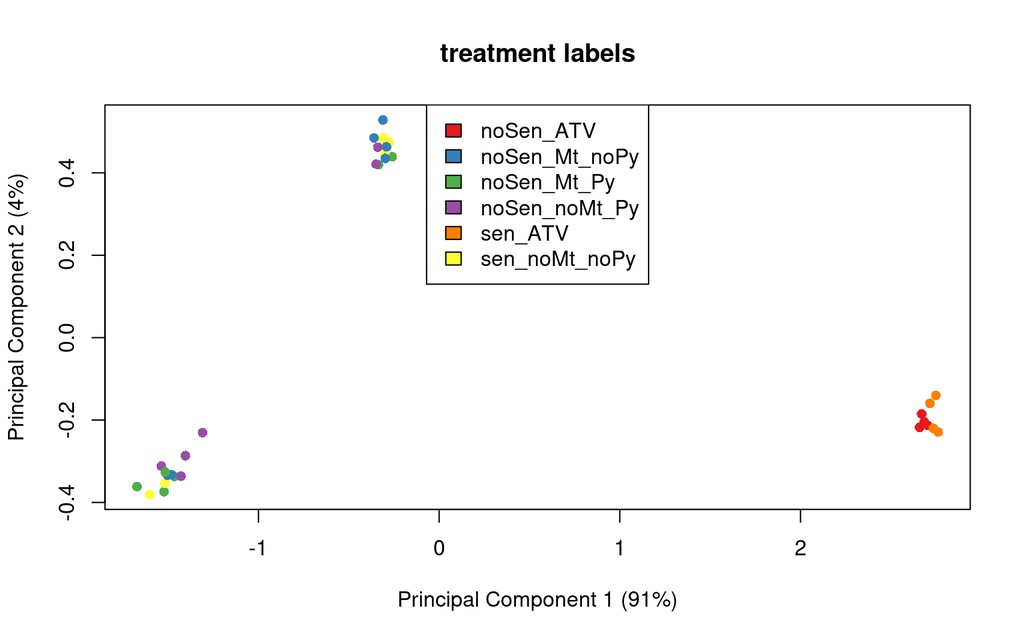

```r
eset_Mvals_clean <- read_rds("../data/formatted/eset_Mvals_MS_clean.rds")
plot_MDS(mylabel = "treatment", myeset = eset_Mvals_clean)
```

```r
#plotMDS(eset_sub, label = pData(eset_sub)[["sampleID"]], gene.selection = "common",
#   main = "ATV sample IDs", pch = 16)
```

## 4.3 Regressing out chip effects

Does regressing out chip effects remove data clustering?

First, remove probes with any missings, then extract residuals from lm adjusting for chip.

Then, run perform PCA, and examine PCA plot of original probe data and the residuals.

```r
eset_Mvals_clean <- read_rds("../data/formatted/eset_Mvals_MS_clean.rds")
e <- exprs(eset_Mvals_clean)
pdat <- pData(eset_Mvals_clean)
sum(colnames(e) != pdat$sampleID)
```

```
## [1] 0
```

```r
lm_fun <- function(cg, dataModel){
    out <- tryCatch({
      lm1 <- lm(cg ~ chip, data = dataModel, na.action = na.omit)
      resid1 <- resid(lm1)
      return(resid1)
    },
    error = function(e) rep(NA, 32)
            )
}

e <- t(e)
e_df <- as.data.frame(e)
#remove probes with any missings because PCA fails with missings
count_vals <- map_int(e_df, ~ sum(!is.na(.)))
e_df <- e_df[,count_vals == 32]
e_resid <- map_dfc(e_df, lm_fun, dataModel = pdat)

library(ggfortify)
#PCA of original data
eset_pca <- prcomp(e_df, center = TRUE, scale = TRUE)
summary(eset_pca)
```

```
## Importance of components:
##                             PC1      PC2       PC3       PC4       PC5       PC6       PC7       PC8      PC9     PC10     PC11     PC12     PC13     PC14     PC15     PC16     PC17     PC18    PC19     PC20     PC21
## Standard deviation     514.5205 315.6597 239.35670 158.90600 119.61473 109.11891 104.20362 101.24476 99.91276 98.87759 97.57474 97.39150 97.02460 96.50695 96.08710 95.24907 95.04583 94.21380 93.8064 93.37764 92.63779
## Proportion of Variance   0.3821   0.1438   0.08269   0.03644   0.02065   0.01718   0.01567   0.01479  0.01441  0.01411  0.01374  0.01369  0.01359  0.01344  0.01333  0.01309  0.01304  0.01281  0.0127  0.01258  0.01239
## Cumulative Proportion    0.3821   0.5259   0.60857   0.64501   0.66566   0.68285   0.69852   0.71331  0.72772  0.74183  0.75557  0.76926  0.78285  0.79629  0.80961  0.82271  0.83574  0.84856  0.8613  0.87384  0.88623
##                            PC22     PC23     PC24     PC25     PC26     PC27     PC28     PC29     PC30     PC31      PC32
## Standard deviation     92.16676 90.93543 90.65672 90.13845 89.14458 89.00763 88.01330 87.17070 86.14067 84.20163 1.227e-12
## Proportion of Variance  0.01226  0.01193  0.01186  0.01173  0.01147  0.01143  0.01118  0.01097  0.01071  0.01023 0.000e+00
## Cumulative Proportion   0.89849  0.91042  0.92228  0.93401  0.94548  0.95691  0.96809  0.97906  0.98977  1.00000 1.000e+00
```

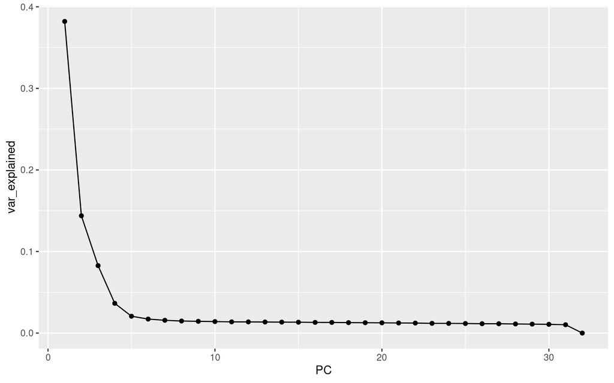

```r
#eset_pca$x
eset_PC <- eset_pca[["x"]]
pdat <- pdat %>%
    mutate(PC1 = eset_PC[,"PC1"],
           PC2 = eset_PC[,"PC2"],
           PC3 = eset_PC[,"PC3"])
#Save new PCs to eset object
pData(eset_Mvals_clean) <- pdat
write_rds(eset_Mvals_clean, file = "../data/formatted/eset_Mvals_MS_cleanPC.rds")

var_explained <- eset_pca$sdev^2 / sum(eset_pca$sdev^2)
data.frame("var_explained" = var_explained, "PC" = seq_along(var_explained)) %>%
    ggplot(mapping = aes(x = PC, y = var_explained)) +
    geom_point() +
    geom_line()
```

```r
myrownames <- paste(pdat$treatment, seq_along(pdat$treatment), sep = "_")
rownames(pdat) <- myrownames
```

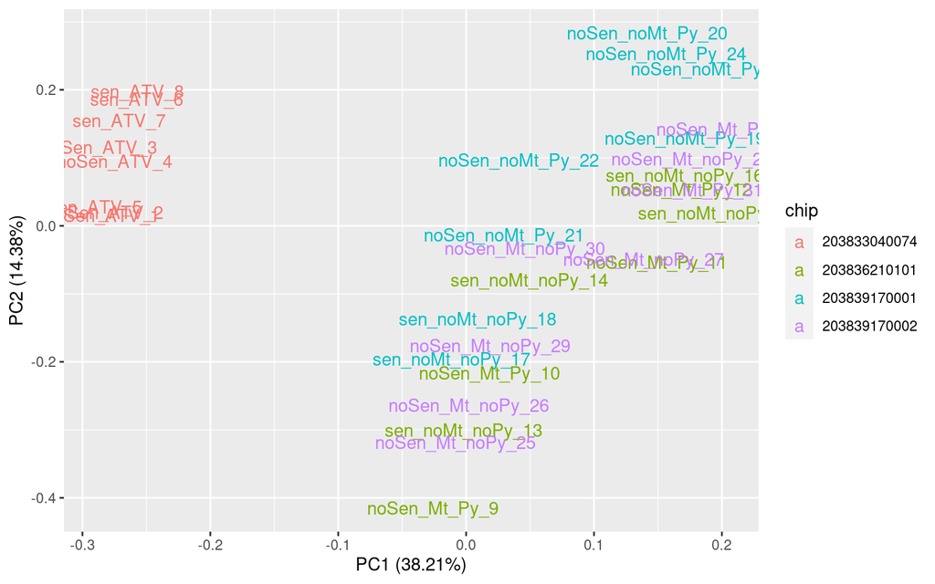

```r
autoplot(eset_pca, data = pdat, colour = "chip", label = TRUE, shape = FALSE)
```

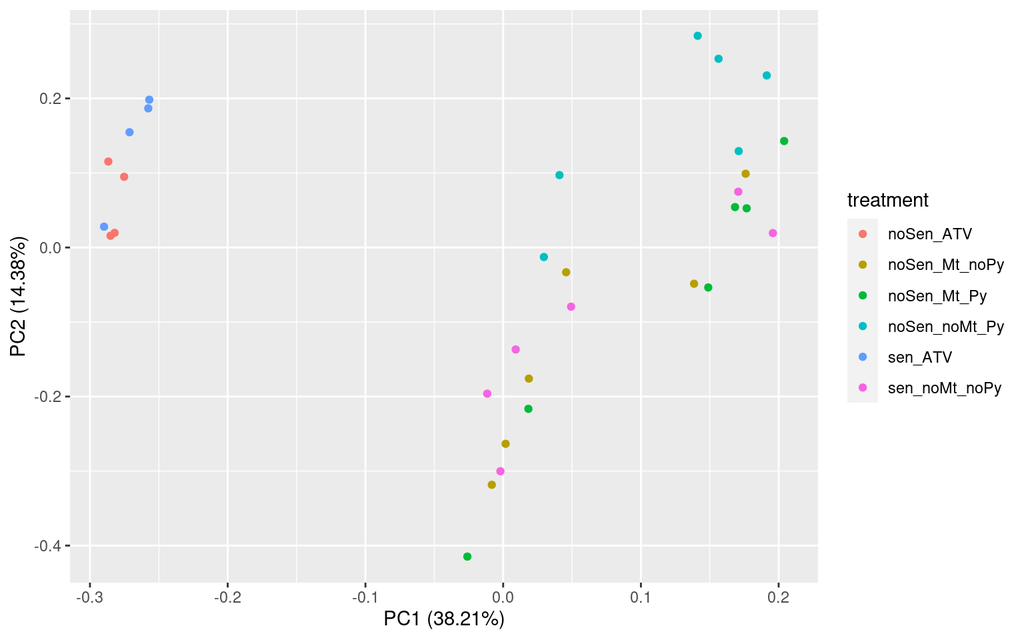

```r
#ggsave(filename = "PCA_e_chip.png")

autoplot(eset_pca, data = pdat, colour = "treatment")
```

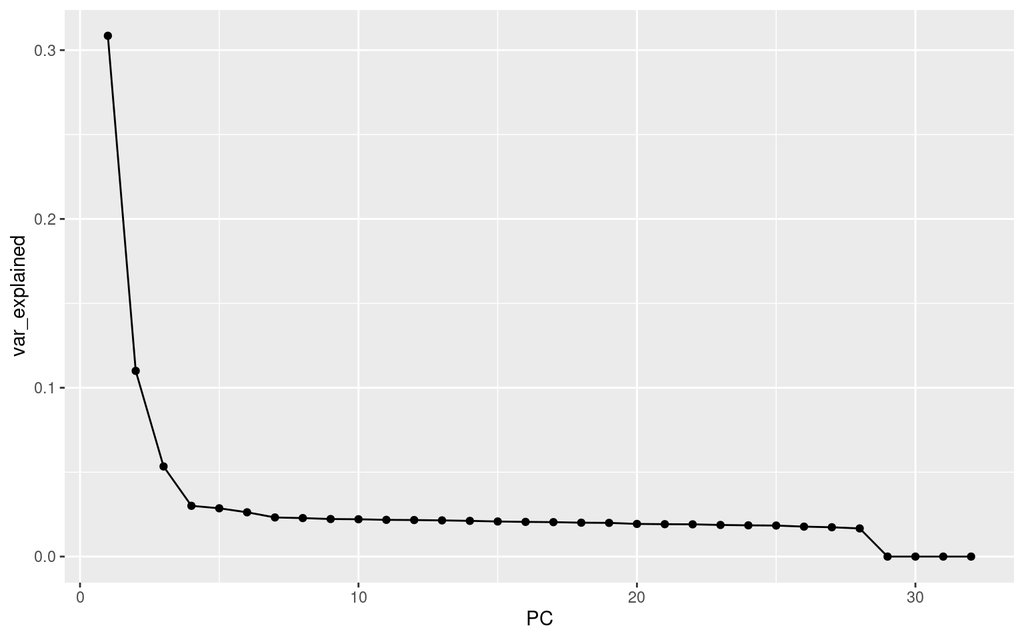

```r
#ggsave(filename = "PCA_e_treatment.png")

#PCA of residuals
eset_pca_resid <- prcomp(e_resid, center = TRUE, scale = TRUE)
var_explained <- eset_pca_resid$sdev^2 / sum(eset_pca_resid$sdev^2)
data.frame("var_explained" = var_explained, "PC" = seq_along(var_explained)) %>%
    ggplot(mapping = aes(x = PC, y = var_explained)) +
    geom_point() +
    geom_line()
```

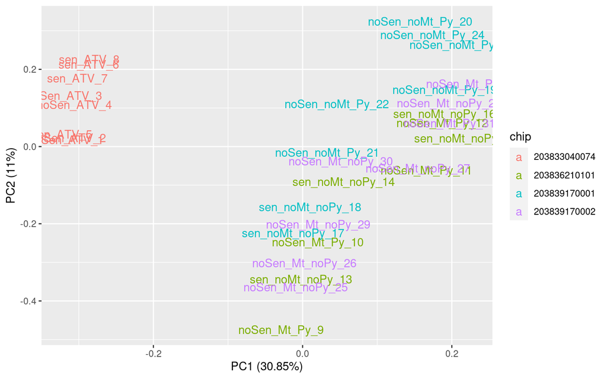

```r
#summary(eset_pca)
autoplot(eset_pca_resid, data = pdat, colour = "chip", label = TRUE, shape = FALSE)
```

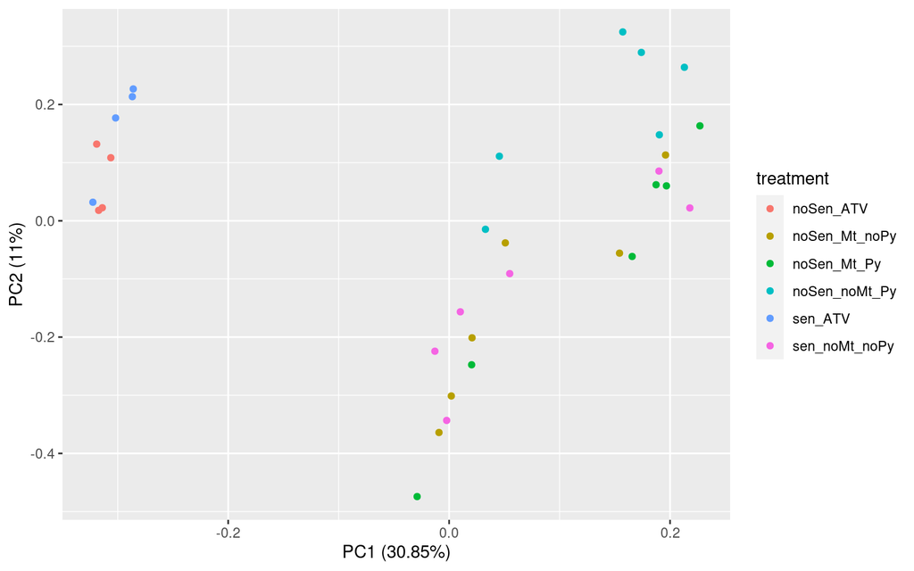

```r
#ggsave(filename = "PCA_resid_chip.png")

autoplot(eset_pca_resid, data = pdat, colour = "treatment")
```

```r
#ggsave(filename = "PCA_resid_treatment.png")
```

# 5 Probe-wise analysis of senescence treatment

## 5.1 Model parameterization

Group means parameterization. No intercept.

$$Y = B_1X_1 + B_2X_2 + B_3X_3 + B_4X_4 + B_5X_5 + B_6X_6 + \epsilon$$

$B_1$ = mean expression level in noSen_ATV.

$B_2$ = mean expression level in noSen_Mt_Py.

$B_3$ = mean expression level in noSen_Mt_noPy.

$B_4$ = mean expression level in noSen_noMt_Py.

$B_5$ = mean expression level in sen_ATV.

$B_6$ = mean expression level in sen_noMt_noPy.

After model fit, contrasts are set that represent difference in group means.

logFC = estimate of the log2-fold-change

CI.L = lower 95% confidence interval for logFC

CI.R = upper 95% confidence interval for logFC

AveExpr = average log2-expression for the probe over all samples

t = moderated t-statistic

P.value = unadjusted P-value

adj.P.value = BH 1995 adjusted P-value

B = log-odds that the variable is differentially abundant.

From the limma user guide: Suppose for example that B = 1.5. The odds of differential expression is exp(1.5)=4.48, i.e, about four and a half to one. The probability that the gene is differentially expressed is 4.48/(1+4.48)=0.82, i.e., the probability is about 82% that this gene is differentially expressed. A B-statistic of zero corresponds to a 50-50 chance that the gene is differentially expressed. The B-statistic is automatically adjusted for multiple testing by assuming that 1% of the genes are expected to be differentially expressed. The p-values and B-statistics will normally rank genes in the same order.

## 5.2 No adjustment

Not adjusted for chip or PCs. Inflated results.

```r
eset_Mvals_clean <- read_rds("../data/formatted/eset_Mvals_MS_cleanPC.rds")
my_pData <- pData(eset_Mvals_clean)
design <- model.matrix(~0 + treatment, data = my_pData)
colSums(design)
```

```
##     treatmentnoSen_ATV treatmentnoSen_Mt_noPy   treatmentnoSen_Mt_Py treatmentnoSen_noMt_Py       treatmentsen_ATV treatmentsen_noMt_noPy
##                      4                      6                      6                      6                      4                      6
```

```r
cm <- makeContrasts(ATVvControl = treatmentsen_ATV - treatmentnoSen_ATV,
            SenMidasvNoSenMtnoPy = treatmentsen_noMt_noPy - treatmentnoSen_Mt_noPy,
            SenMidasvNoSenNoMtPy = treatmentsen_noMt_noPy - treatmentnoSen_noMt_Py,
            levels = design
            )
fit <- lmFit(eset_Mvals_clean, design)
fit2 <- contrasts.fit(fit, contrasts = cm)
fit2 <- eBayes(fit2)

results <- decideTests(fit2)
summary(results)
```

```
##        ATVvControl SenMidasvNoSenMtnoPy SenMidasvNoSenNoMtPy
## Down             2                    0                13253
## NotSig      701734               701736               681022
## Up               0                    0                 7461
```

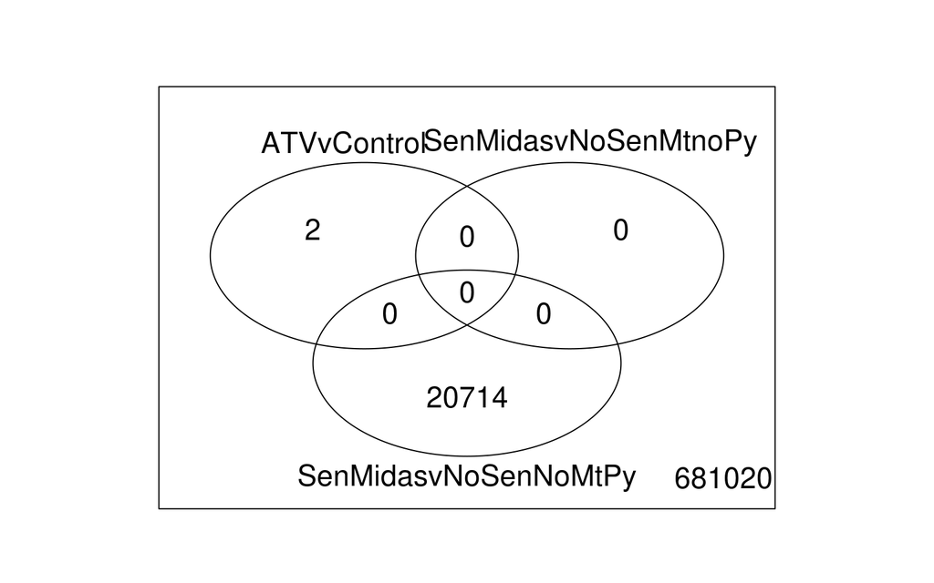

```r
vennDiagram(results)
```

## 5.3 Chip adjustment

```r
eset_Mvals_clean <- read_rds("../data/formatted/eset_Mvals_MS_cleanPC.rds")
my_pData <- pData(eset_Mvals_clean)
design <- model.matrix(~0 + treatment + chip, data = my_pData)
design
```

```
##         treatmentnoSen_ATV treatmentnoSen_Mt_noPy treatmentnoSen_Mt_Py treatmentnoSen_noMt_Py treatmentsen_ATV treatmentsen_noMt_noPy chip203836210101 chip203839170001 chip203839170002
## ATV1                     1                      0                    0                      0                0                      0                0                0                0
## ATV2                     1                      0                    0                      0                0                      0                0                0                0
## ATV3                     1                      0                    0                      0                0                      0                0                0                0
## ATV4                     1                      0                    0                      0                0                      0                0                0                0
## ATV5                     0                      0                    0                      0                1                      0                0                0                0
## ATV6                     0                      0                    0                      0                1                      0                0                0                0
## ATV7                     0                      0                    0                      0                1                      0                0                0                0
## ATV8                     0                      0                    0                      0                1                      0                0                0                0
## midas1                   0                      0                    1                      0                0                      0                1                0                0
## midas2                   0                      0                    1                      0                0                      0                1                0                0
## midas3                   0                      0                    1                      0                0                      0                1                0                0
## midas4                   0                      0                    1                      0                0                      0                1                0                0
## midas5                   0                      0                    0                      0                0                      1                1                0                0
## midas6                   0                      0                    0                      0                0                      1                1                0                0
## midas7                   0                      0                    0                      0                0                      1                1                0                0
## midas8                   0                      0                    0                      0                0                      1                1                0                0
## midas9                   0                      0                    0                      0                0                      1                0                1                0
## midas10                  0                      0                    0                      0                0                      1                0                1                0
## midas11                  0                      0                    0                      1                0                      0                0                1                0
## midas12                  0                      0                    0                      1                0                      0                0                1                0
## midas13                  0                      0                    0                      1                0                      0                0                1                0
## midas14                  0                      0                    0                      1                0                      0                0                1                0
## midas15                  0                      0                    0                      1                0                      0                0                1                0
## midas16                  0                      0                    0                      1                0                      0                0                1                0
## midas17                  0                      1                    0                      0                0                      0                0                0                1
## midas18                  0                      1                    0                      0                0                      0                0                0                1
```

[output cut: 14 more lines]

```r
colSums(design)
```

```
##     treatmentnoSen_ATV treatmentnoSen_Mt_noPy   treatmentnoSen_Mt_Py treatmentnoSen_noMt_Py       treatmentsen_ATV treatmentsen_noMt_noPy       chip203836210101       chip203839170001       chip203839170002
##                      4                      6                      6                      6                      4                      6                      8                      8                      8
```

```r
cm <- makeContrasts(ATVvControl = treatmentsen_ATV - treatmentnoSen_ATV,
            SenMidasvNoSenMtnoPy = treatmentsen_noMt_noPy - treatmentnoSen_Mt_noPy,
            SenMidasvNoSenNoMtPy = treatmentsen_noMt_noPy - treatmentnoSen_noMt_Py,
            levels = design
            )
fit <- lmFit(eset_Mvals_clean, design)
```

```
## Coefficients not estimable: chip203839170002
```

```r
fit2 <- contrasts.fit(fit, contrasts = cm)
fit2 <- eBayes(fit2)

results <- decideTests(fit2)
summary(results)
```

```
##        ATVvControl SenMidasvNoSenMtnoPy SenMidasvNoSenNoMtPy
## Down             2                    0                    1
## NotSig      701734               701736               701734
## Up               0                    0                    1
```

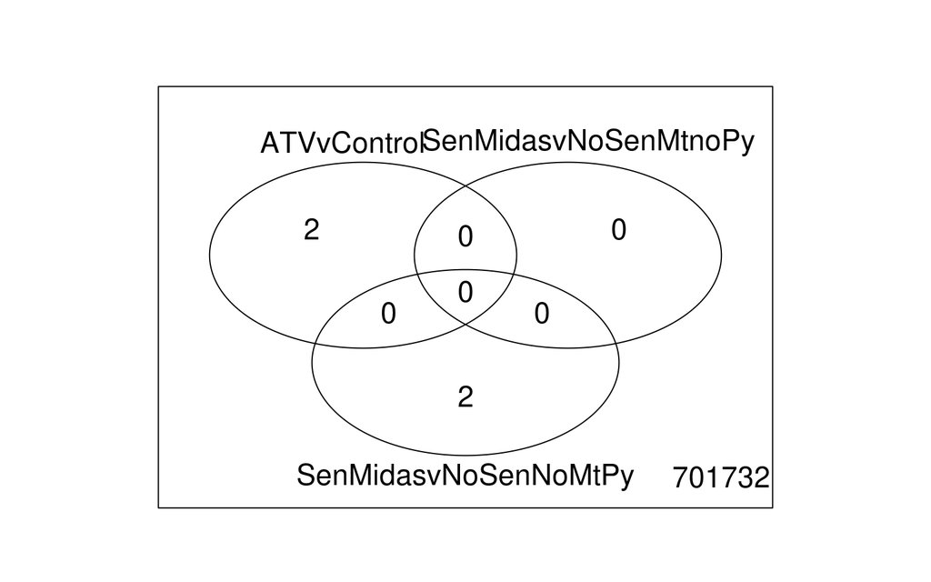

```r
vennDiagram(results)
```

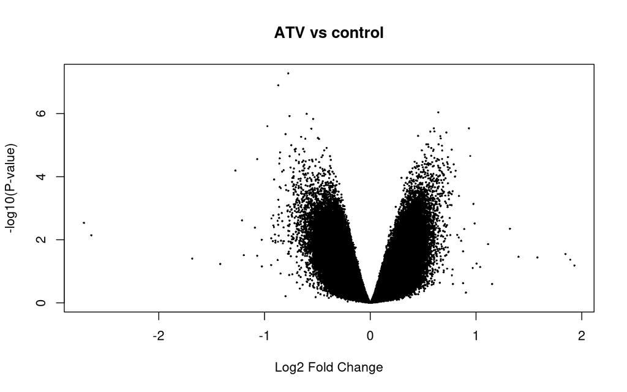

```r
volcanoplot(fit2, coef = "ATVvControl" , main = "ATV vs control")
```

```r
annot_cols <- c("CpG_chrm", "CpG_beg", "probeID", "gene")
topTable(fit2, coef = "ATVvControl", genelist = fit2$genes[,annot_cols],
     p.value = 0.05, confint = TRUE) %>%
    kable()
```

|  | CpG_chrm | CpG_beg | probeID | gene | logFC | CI.L | CI.R | AveExpr | t | P.Value | adj.P.Val | B |
| --- | --- | --- | --- | --- | --- | --- | --- | --- | --- | --- | --- | --- |
| cg05454501 | chr5 | 76373390 | cg05454501 | ZBED3 | -0.7758949 | -1.011240 | -0.5405496 | -5.140061 | -7.356898 | 1e-07 | 0.0374536 | 5.447081 |
| cg15587508 | chr1 | 27286599 | cg15587508 | KDF1 | -0.8705465 | -1.076502 | -0.6645910 | -5.330129 | -7.019194 | 1e-07 | 0.0445008 | 4.932323 |

```r
topTable(fit2, coef = "SenMidasvNoSenMtnoPy", genelist = fit2$genes[,annot_cols],
     p.value = 0.05, confint = TRUE) %>%
    kable()
```

[output not shown]

```r
topTable(fit2, coef = "SenMidasvNoSenNoMtPy", genelist = fit2$genes[,annot_cols],
     p.value = 0.05, confint = TRUE) %>%
    kable()
```

|  | CpG_chrm | CpG_beg | probeID | gene | logFC | CI.L | CI.R | AveExpr | t | P.Value | adj.P.Val | B |
| --- | --- | --- | --- | --- | --- | --- | --- | --- | --- | --- | --- | --- |
| cg06092146 | chr12 | 34504447 | cg06092146 | NA | 2.786122 | 2.514369 | 3.0578757 | 3.692039 | 9.432488 | 0 | 0.0002520 | 11.511421 |
| cg21910919 | chr12 | 27123456 | cg21910919 | RP11-421F16.3 | -1.021855 | -1.259672 | -0.7840379 | 4.584737 | -8.151618 | 0 | 0.0025823 | 9.192936 |

```r
#save results
resultAll <- topTable(fit2, coef = "ATVvControl", sort.by = "none", number = nrow(fit2), confint = TRUE)
write_csv(resultAll, file = paste0(dir_out, "ATVvControl_chip.csv"))
resultAll <- topTable(fit2, coef = "SenMidasvNoSenMtnoPy", sort.by = "none", number = nrow(fit2), confint = TRUE)
write_csv(resultAll, file = paste0(dir_out, "SenMidasvNoSenMtnoPy_chip.csv"))
resultAll <- topTable(fit2, coef = "SenMidasvNoSenNoMtPy", sort.by = "none", number = nrow(fit2), confint = TRUE)
write_csv(resultAll, file = paste0(dir_out, "SenMidasvNoSenNoMtPy_chip.csv"))
```

## 5.4 Chip and PC adjustment

```r
eset_Mvals_clean <- read_rds("../data/formatted/eset_Mvals_MS_cleanPC.rds")
my_pData <- pData(eset_Mvals_clean)
design <- model.matrix(~0 + treatment + chip + PC1 + PC2, data = my_pData)
design
```

```
##         treatmentnoSen_ATV treatmentnoSen_Mt_noPy treatmentnoSen_Mt_Py treatmentnoSen_noMt_Py treatmentsen_ATV treatmentsen_noMt_noPy chip203836210101 chip203839170001 chip203839170002         PC1        PC2
## ATV1                     1                      0                    0                      0                0                      0                0                0                0 -829.668616   28.00612
## ATV2                     1                      0                    0                      0                0                      0                0                0                0 -821.046812   34.98886
## ATV3                     1                      0                    0                      0                0                      0                0                0                0 -834.386610  205.92652
## ATV4                     1                      0                    0                      0                0                      0                0                0                0 -800.925395  169.38385
## ATV5                     0                      0                    0                      0                1                      0                0                0                0 -843.410382   49.84736
## ATV6                     0                      0                    0                      0                1                      0                0                0                0 -749.988492  333.35131
## ATV7                     0                      0                    0                      0                1                      0                0                0                0 -789.576672  276.16996
## ATV8                     0                      0                    0                      0                1                      0                0                0                0 -747.804783  354.09750
## midas1                   0                      0                    1                      0                0                      0                1                0                0  -75.711775 -740.60976
## midas2                   0                      0                    1                      0                0                      0                1                0                0   53.293372 -386.67118
## midas3                   0                      0                    1                      0                0                      0                1                0                0  433.365003  -95.80694
## midas4                   0                      0                    1                      0                0                      0                1                0                0  489.961567   96.77728
## midas5                   0                      0                    0                      0                0                      1                1                0                0   -5.803939 -536.10152
## midas6                   0                      0                    0                      0                0                      1                1                0                0  143.507795 -141.84113
## midas7                   0                      0                    0                      0                0                      1                1                0                0  569.926017   34.48616
## midas8                   0                      0                    0                      0                0                      1                1                0                0  496.790723  133.52215
## midas9                   0                      0                    0                      0                0                      1                0                1                0  -33.684285 -350.24624
## midas10                  0                      0                    0                      0                0                      1                0                1                0   26.541872 -244.45833
## midas11                  0                      0                    0                      1                0                      0                0                1                0  497.720905  230.91919
## midas12                  0                      0                    0                      1                0                      0                0                1                0  411.084573  507.21464
## midas13                  0                      0                    0                      1                0                      0                0                1                0   86.047812  -22.84358
## midas14                  0                      0                    0                      1                0                      0                0                1                0  118.997813  173.43657
## midas15                  0                      0                    0                      1                0                      0                0                1                0  557.009361  412.22402
## midas16                  0                      0                    0                      1                0                      0                0                1                0  455.119972  452.10143
## midas17                  0                      1                    0                      0                0                      0                0                0                1  -24.007488 -568.57610
## midas18                  0                      1                    0                      0                0                      0                0                0                1    5.199747 -470.42775
```

[output cut: 14 more lines]

```r
colSums(design)
```

```
##     treatmentnoSen_ATV treatmentnoSen_Mt_noPy   treatmentnoSen_Mt_Py treatmentnoSen_noMt_Py       treatmentsen_ATV treatmentsen_noMt_noPy       chip203836210101       chip203839170001       chip203839170002
##           4.000000e+00           6.000000e+00           6.000000e+00           6.000000e+00           4.000000e+00           6.000000e+00           8.000000e+00           8.000000e+00           8.000000e+00
##                    PC1                    PC2
##           1.217693e-12          -6.288303e-13
```

```r
cm <- makeContrasts(ATVvControl = treatmentsen_ATV - treatmentnoSen_ATV,
            SenMidasvNoSenMtnoPy = treatmentsen_noMt_noPy - treatmentnoSen_Mt_noPy,
            SenMidasvNoSenNoMtPy = treatmentsen_noMt_noPy - treatmentnoSen_noMt_Py,
            levels = design
            )
fit <- lmFit(eset_Mvals_clean, design)
```

```
## Coefficients not estimable: chip203839170002
```

```r
fit2 <- contrasts.fit(fit, contrasts = cm)
fit2 <- eBayes(fit2)

results <- decideTests(fit2)
summary(results)
```

```
##        ATVvControl SenMidasvNoSenMtnoPy SenMidasvNoSenNoMtPy
## Down             3                    0                    1
## NotSig      701730               701735               701734
## Up               3                    1                    1
```

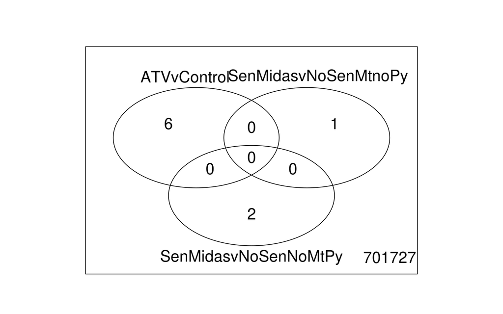

```r
vennDiagram(results)
```

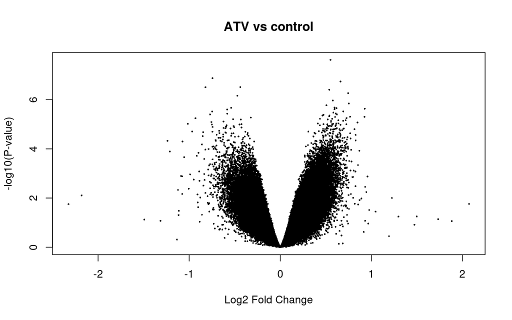

```r
volcanoplot(fit2, coef = "ATVvControl" , main = "ATV vs control")
```

```r
annot_cols <- c("CpG_chrm", "CpG_beg", "probeID", "gene")
topTable(fit2, coef = "ATVvControl", genelist = fit2$genes[,annot_cols],
     p.value = 0.05, confint = TRUE) %>%
    kable()
```

|  | CpG_chrm | CpG_beg | probeID | gene | logFC | CI.L | CI.R | AveExpr | t | P.Value | adj.P.Val | B |
| --- | --- | --- | --- | --- | --- | --- | --- | --- | --- | --- | --- | --- |
| cg14312323 | chr17 | 47980309 | cg14312323 | NA | 0.5514996 | 0.3317219 | 0.7712773 | 2.6999015 | 7.757149 | 0e+00 | 0.0170061 | 7.400637 |
| cg05454501 | chr5 | 76373390 | cg05454501 | ZBED3 | -0.7444368 | -0.9095453 | -0.5793283 | -5.1400615 | -7.071579 | 1e-07 | 0.0428197 | 6.178655 |
| cg04747792 | chr10 | 131724421 | cg04747792 | EBF3 | 0.6619253 | 0.4853346 | 0.8385159 | 2.3305877 | 6.945010 | 2e-07 | 0.0428197 | 5.944021 |
| cg24814257 | chr19 | 42212500 | cg24814257 | AC011513.3;CEACAM5 | -0.4385099 | -0.6096650 | -0.2673547 | -2.2036598 | -6.741880 | 3e-07 | 0.0439143 | 5.561725 |
| cg15587508 | chr1 | 27286599 | cg15587508 | KDF1 | -0.8211396 | -1.0625092 | -0.5797699 | -5.3301293 | -6.734875 | 3e-07 | 0.0439143 | 5.548416 |
| cg19567758 | chr17 | 80135999 | cg19567758 | CCDC57 | 0.5380297 | 0.3689480 | 0.7071113 | 0.7542219 | 6.645951 | 4e-07 | 0.0459823 | 5.378769 |

```r
topTable(fit2, coef = "SenMidasvNoSenMtnoPy", genelist = fit2$genes[,annot_cols],
     p.value = 0.05, confint = TRUE) %>%
    kable()
```

|  | CpG_chrm | CpG_beg | probeID | gene | logFC | CI.L | CI.R | AveExpr | t | P.Value | adj.P.Val | B |
| --- | --- | --- | --- | --- | --- | --- | --- | --- | --- | --- | --- | --- |
| cg26636613 | chr8 | 41677116 | cg26636613 | ANK1 | 0.9530541 | 0.6672077 | 1.238901 | 4.311539 | 7.504185 | 0 | 0.0316455 | 7.246781 |

```r
topTable(fit2, coef = "SenMidasvNoSenNoMtPy", genelist = fit2$genes[,annot_cols],
     p.value = 0.05, confint = TRUE) %>%
    kable()
```

|  | CpG_chrm | CpG_beg | probeID | gene | logFC | CI.L | CI.R | AveExpr | t | P.Value | adj.P.Val | B |
| --- | --- | --- | --- | --- | --- | --- | --- | --- | --- | --- | --- | --- |
| cg06092146 | chr12 | 34504447 | cg06092146 | NA | 2.382082 | 2.147508 | 2.616655 | 3.692039 | 7.673610 | 0e+00 | 0.0208584 | 2.479714 |
| cg09439093 | chr6 | 4135574 | cg09439093 | ECI2;RP3-400B16.1;RP3-400B16.4 | -1.343365 | -1.562686 | -1.124044 | -3.316120 | -7.104423 | 1e-07 | 0.0429140 | 1.990811 |

```r
#save results
resultAll <- topTable(fit2, coef = "ATVvControl", sort.by = "none", number = nrow(fit2), confint = TRUE)
write_csv(resultAll, file = paste0(dir_out, "ATVvControl_chipPC.csv"))
resultAll <- topTable(fit2, coef = "SenMidasvNoSenMtnoPy", sort.by = "none", number = nrow(fit2), confint = TRUE)
write_csv(resultAll, file = paste0(dir_out, "SenMidasvNoSenMtnoPy_chipPC.csv"))
resultAll <- topTable(fit2, coef = "SenMidasvNoSenNoMtPy", sort.by = "none", number = nrow(fit2), confint = TRUE)
write_csv(resultAll, file = paste0(dir_out, "SenMidasvNoSenNoMtPy_chipPC.csv"))
```

## 5.5 Results comparisons

Compare results across 1) chip adjustment and 2) chip and PC adjustment.

```r
dir_out <- "../results/"

for(i in c("ATVvControl", "SenMidasvNoSenMtnoPy", "SenMidasvNoSenNoMtPy")){
  print(paste0("Compare chip and chipPC with contrast ", i))
  print("")

  chip <- read_csv(paste0(dir_out, i, "_chip.csv"))
  chipPC <- read_csv(paste0(dir_out, i, "_chipPC.csv"))
  mycols <- c("probeID", "gene", "logFC", "t", "P.Value", "adj.P.Val")
  chip <- chip %>%
    select(any_of(mycols))
  names(chip)[3:6] <- paste(names(chip)[3:6], "chip", sep = "_")
  chipPC <- chipPC %>%
    select(any_of(mycols))
  names(chipPC)[3:6] <- paste(names(chipPC)[3:6], "chipPC", sep = "_")

  t1 <- chipPC %>%
    filter(adj.P.Val_chipPC <= 0.05) %>%
    left_join(chip, by = "probeID") %>%
    modify_if(is.double, ~ signif(., 3)) %>%
    kbl() %>%
    kable_styling(bootstrap_options = c("striped", "hover"))
  print(t1)

  datMerge <- inner_join(chip, chipPC, by = "probeID")
  print(paste("Correlation of t-statistics from chip and chipPC adjusted",
          cor(datMerge$t_chip, datMerge$t_chipPC)
          )
  )

  p1 <- chipPC %>%
    inner_join(chip, by = "probeID") %>%
    filter(!is.na(t_chip)) %>%
    filter(!is.na(t_chipPC)) %>%
    ggplot(aes(x = t_chip, y = t_chipPC)) +
    geom_hex() +
    #geom_hex(binwidth = c(cor1, cor1)) +
    labs(x = "Adjusted chip",
         y = "Adjusted chip and PCs",
         caption = i)
  print(p1)


}
```

[1] “Compare chip and chipPC with contrast ATVvControl” [1] ""

| probeID | gene.x | logFC_chipPC | t_chipPC | P.Value_chipPC | adj.P.Val_chipPC | gene.y | logFC_chip | t_chip | P.Value_chip | adj.P.Val_chip |
| --- | --- | --- | --- | --- | --- | --- | --- | --- | --- | --- |
| cg04747792 | EBF3 | 0.662 | 6.95 | 2e-07 | 0.0428 | EBF3 | 0.567 | 3.37 | 2.19e-03 | 0.5420 |
| cg05454501 | ZBED3 | -0.744 | -7.07 | 1e-07 | 0.0428 | ZBED3 | -0.776 | -7.36 | 1.00e-07 | 0.0375 |
| cg14312323 | NA | 0.551 | 7.76 | 0e+00 | 0.0170 | NA | 0.497 | 4.79 | 5.04e-05 | 0.3210 |
| cg15587508 | KDF1 | -0.821 | -6.73 | 3e-07 | 0.0439 | KDF1 | -0.871 | -7.02 | 1.00e-07 | 0.0445 |
| cg19567758 | CCDC57 | 0.538 | 6.65 | 4e-07 | 0.0460 | CCDC57 | 0.476 | 2.26 | 3.15e-02 | 0.7510 |
| cg24814257 | AC011513.3;CEACAM5 | -0.439 | -6.74 | 3e-07 | 0.0439 | AC011513.3;CEACAM5 | -0.461 | -5.06 | 2.41e-05 | 0.3180 |

[1] “Correlation of t-statistics from chip and chipPC adjusted 0.886620499031124”

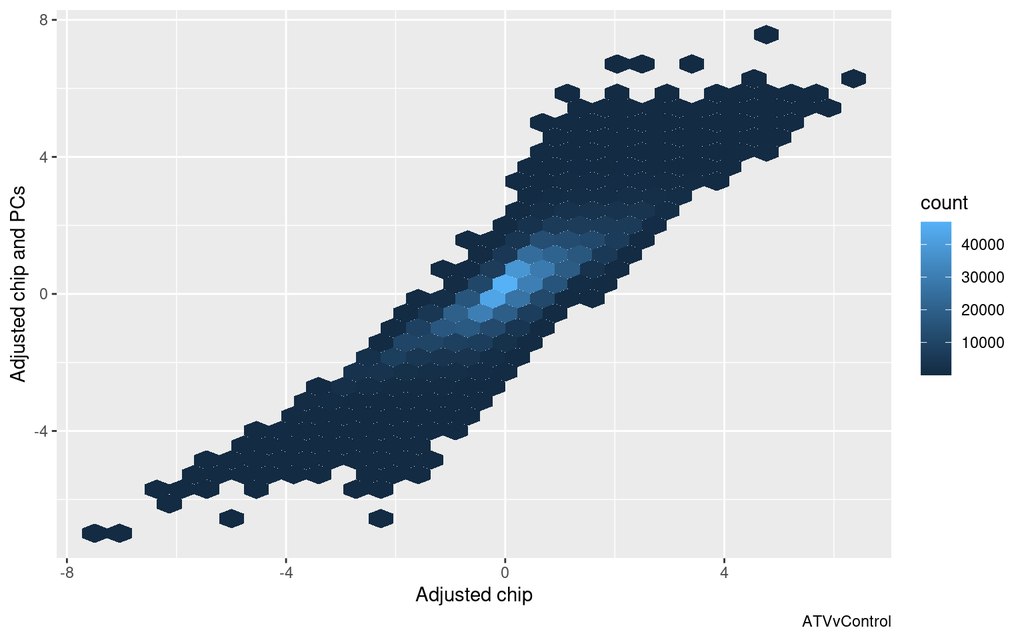

[1] “Compare chip and chipPC with contrast SenMidasvNoSenMtnoPy” [1] ""

| probeID | gene.x | logFC_chipPC | t_chipPC | P.Value_chipPC | adj.P.Val_chipPC | gene.y | logFC_chip | t_chip | P.Value_chip | adj.P.Val_chip |
| --- | --- | --- | --- | --- | --- | --- | --- | --- | --- | --- |
| cg26636613 | ANK1 | 0.953 | 7.5 | 0 | 0.0316 | ANK1 | 0.832 | 4.71 | 6.25e-05 | 0.15 |

[1] “Correlation of t-statistics from chip and chipPC adjusted 0.55279835591272”

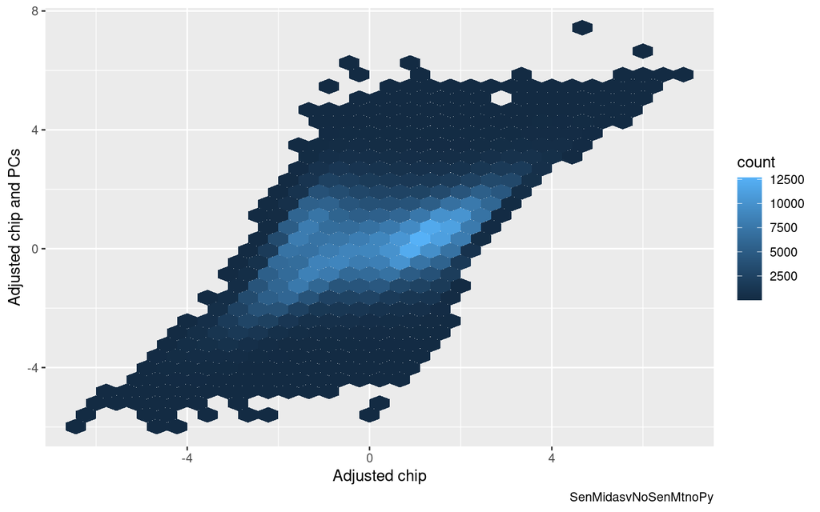

[1] “Compare chip and chipPC with contrast SenMidasvNoSenNoMtPy” [1] ""

| probeID | gene.x | logFC_chipPC | t_chipPC | P.Value_chipPC | adj.P.Val_chipPC | gene.y | logFC_chip | t_chip | P.Value_chip | adj.P.Val_chip |
| --- | --- | --- | --- | --- | --- | --- | --- | --- | --- | --- |
| cg06092146 | NA | 2.38 | 7.67 | 0e+00 | 0.0209 | NA | 2.79 | 9.43 | 0.000000 | 0.000252 |
| cg09439093 | ECI2;RP3-400B16.1;RP3-400B16.4 | -1.34 | -7.10 | 1e-07 | 0.0429 | ECI2;RP3-400B16.1;RP3-400B16.4 | -0.86 | -4.04 | 0.000382 | 0.109000 |

[1] “Correlation of t-statistics from chip and chipPC adjusted 0.462726283280423”

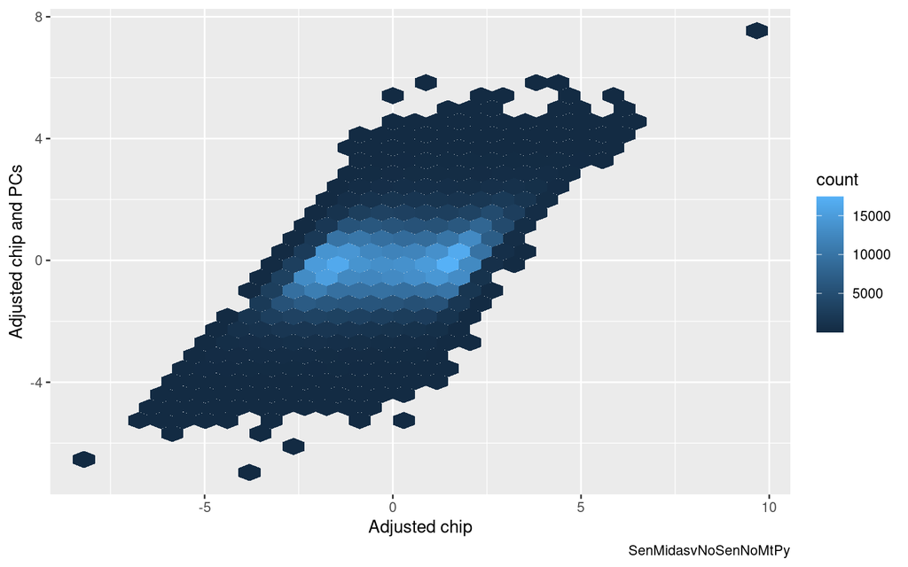

# 6 ComBat known batch effects

Adjust for known batch effects with Combat. Clearly, plate is a batch effect. ComBat provides an empirical bayesian approach to output data adjusted for batches that is more effective than simply including batch in a regression model.

Two related problems.

1. Removing batch effects with ComBat can introduce a correlation structure into the adjusted, batch-corrected data. Specifically, correlation is induced between adjusted data points within a batch. See (https://www.biorxiv.org/content/biorxiv/early/2021/01/25/2021.01.24.428009.full.pdf). This is from Evan Johnson group, who developed SVA package.
2. ATV sen and controls were done on one plate. The ComBat-induced correlation between data points within a batch/plate makes samples more similar, reducing the differential probe quantity between ATV sen and controls.

```r
library(sva)

eset_Mvals_clean <- read_rds("../data/formatted/eset_Mvals_MS_clean.rds")
e <- exprs(eset_Mvals_clean)
pdat <- pData(eset_Mvals_clean)
sum(colnames(e) != pdat$sampleID)
```

```
## [1] 0
```

```r
pdat %>%
    select(treatment, chip) %>%
    arrange(chip, treatment) %>%
    kable
```

| treatment | chip |
| --- | --- |
| noSen_ATV | 203833040074 |
| noSen_ATV | 203833040074 |
| noSen_ATV | 203833040074 |
| noSen_ATV | 203833040074 |
| sen_ATV | 203833040074 |
| sen_ATV | 203833040074 |
| sen_ATV | 203833040074 |
| sen_ATV | 203833040074 |
| noSen_Mt_Py | 203836210101 |
| noSen_Mt_Py | 203836210101 |
| noSen_Mt_Py | 203836210101 |
| noSen_Mt_Py | 203836210101 |
| sen_noMt_noPy | 203836210101 |
| sen_noMt_noPy | 203836210101 |
| sen_noMt_noPy | 203836210101 |
| sen_noMt_noPy | 203836210101 |
| noSen_noMt_Py | 203839170001 |
| noSen_noMt_Py | 203839170001 |
| noSen_noMt_Py | 203839170001 |
| noSen_noMt_Py | 203839170001 |
| noSen_noMt_Py | 203839170001 |
| noSen_noMt_Py | 203839170001 |
| sen_noMt_noPy | 203839170001 |
| sen_noMt_noPy | 203839170001 |
| noSen_Mt_noPy | 203839170002 |
| noSen_Mt_noPy | 203839170002 |
| noSen_Mt_noPy | 203839170002 |
| noSen_Mt_noPy | 203839170002 |
| noSen_Mt_noPy | 203839170002 |
| noSen_Mt_noPy | 203839170002 |
| noSen_Mt_Py | 203839170002 |
| noSen_Mt_Py | 203839170002 |

```r
#Set treatment reference level to group not used in modeling
pdat <- pdat %>%
    mutate(treatment = relevel(treatment, ref = "noSen_Mt_Py"))

mod_combat <- model.matrix(~ 1, data = pdat)
#Error if treatment included in model matrix.
#At least one treatment level confounded with batch.
#mod_combat <- model.matrix(~ treatment, data = pdat)
mod_combat
```

```
##         (Intercept)
## ATV1              1
## ATV2              1
## ATV3              1
## ATV4              1
## ATV5              1
## ATV6              1
## ATV7              1
## ATV8              1
## midas1            1
## midas2            1
## midas3            1
## midas4            1
## midas5            1
## midas6            1
## midas7            1
## midas8            1
## midas9            1
## midas10           1
## midas11           1
## midas12           1
## midas13           1
## midas14           1
## midas15           1
## midas16           1
## midas17           1
## midas18           1
## midas19           1
## midas20           1
## midas21           1
## midas22           1
## midas23           1
## midas24           1
## attr(,"assign")
## [1] 0
```

```r
colSums(mod_combat)
```

```
## (Intercept)
##          32
```

```r
combat_edata <- ComBat(dat = e,
               batch = pdat$chip,
               mod = mod_combat,
               par.prior = TRUE,
               prior.plots = FALSE)
```

```
## Found4batches
```

```
## Adjusting for0covariate(s) or covariate level(s)
```

```
## Found8857Missing Data Values
```

```
## Standardizing Data across genes
```

```
## Fitting L/S model and finding priors
```

```
## Finding parametric adjustments
```

```
## Adjusting the Data
```

```r
combat_edataT <- t(combat_edata)
e_df <- as.data.frame(combat_edataT)
#remove probes with any missings because PCA fails with missings
count_vals <- map_int(e_df, ~ sum(!is.na(.)))
e_df <- e_df[,count_vals == 32]

library(ggfortify)
#PCA of combat corrected data
eset_pca <- prcomp(e_df, center = TRUE, scale = TRUE)
summary(eset_pca)
```

```
## Importance of components:
##                             PC1      PC2       PC3       PC4       PC5       PC6       PC7       PC8      PC9      PC10      PC11      PC12      PC13      PC14      PC15      PC16      PC17     PC18      PC19      PC20
## Standard deviation     447.6659 277.4072 194.24905 160.09019 146.20123 141.18674 139.39407 138.47198 136.2761 133.92661 128.61351 119.90023 119.09607 117.65661 116.34551 115.99920 114.67329 114.4401 113.38056 112.78601
## Proportion of Variance   0.2892   0.1111   0.05446   0.03699   0.03085   0.02877   0.02804   0.02767   0.0268   0.02589   0.02387   0.02075   0.02047   0.01998   0.01954   0.01942   0.01898   0.0189   0.01855   0.01836
## Cumulative Proportion    0.2892   0.4003   0.45476   0.49175   0.52260   0.55137   0.57941   0.60708   0.6339   0.65977   0.68365   0.70439   0.72486   0.74484   0.76438   0.78380   0.80278   0.8217   0.84023   0.85859
##                             PC21      PC22      PC23      PC24      PC25      PC26      PC27      PC28     PC29     PC30     PC31      PC32
## Standard deviation     111.76418 110.63136 109.95037 108.72650 107.85040 107.27495 104.40687 103.51694 52.69482 35.46803 23.36422 1.369e-12
## Proportion of Variance   0.01803   0.01766   0.01745   0.01706   0.01679   0.01661   0.01573   0.01547  0.00401  0.00182  0.00079 0.000e+00
## Cumulative Proportion    0.87662   0.89429   0.91173   0.92879   0.94558   0.96219   0.97792   0.99339  0.99740  0.99921  1.00000 1.000e+00
```

```r
myrownames <- paste(pdat$treatment, seq_along(pdat$treatment), sep = "_")
rownames(pdat) <- myrownames
```

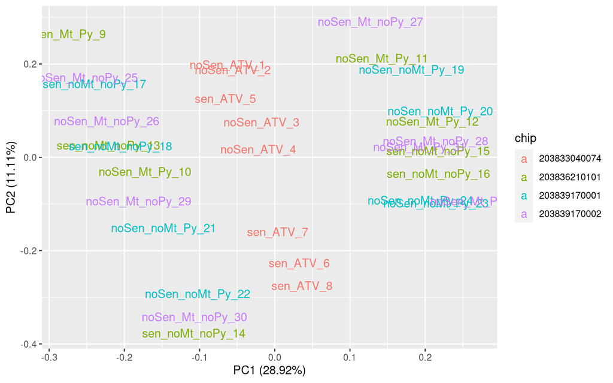

```r
p1 <- autoplot(eset_pca, data = pdat, colour = "chip", label = TRUE, shape = FALSE)
print(p1)
```

```r
ggsave(p1, filename = "PCA_combat_chip.pdf")
```

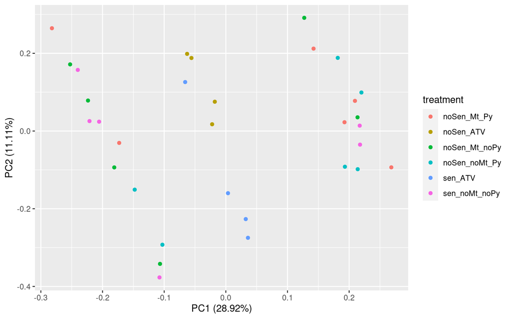

```r
p1 <- autoplot(eset_pca, data = pdat, colour = "treatment")
print(p1)
```

```r
ggsave(p1, filename = "PCA_combat_treatment.pdf")
#Probe analysis of combat edata
mod <- model.matrix(~ 0 + treatment, data = pdat)
mod
```

```
##                  treatmentnoSen_Mt_Py treatmentnoSen_ATV treatmentnoSen_Mt_noPy treatmentnoSen_noMt_Py treatmentsen_ATV treatmentsen_noMt_noPy
## noSen_ATV_1                         0                  1                      0                      0                0                      0
## noSen_ATV_2                         0                  1                      0                      0                0                      0
## noSen_ATV_3                         0                  1                      0                      0                0                      0
## noSen_ATV_4                         0                  1                      0                      0                0                      0
## sen_ATV_5                           0                  0                      0                      0                1                      0
## sen_ATV_6                           0                  0                      0                      0                1                      0
## sen_ATV_7                           0                  0                      0                      0                1                      0
## sen_ATV_8                           0                  0                      0                      0                1                      0
## noSen_Mt_Py_9                       1                  0                      0                      0                0                      0
## noSen_Mt_Py_10                      1                  0                      0                      0                0                      0
## noSen_Mt_Py_11                      1                  0                      0                      0                0                      0
## noSen_Mt_Py_12                      1                  0                      0                      0                0                      0
## sen_noMt_noPy_13                    0                  0                      0                      0                0                      1
## sen_noMt_noPy_14                    0                  0                      0                      0                0                      1
## sen_noMt_noPy_15                    0                  0                      0                      0                0                      1
## sen_noMt_noPy_16                    0                  0                      0                      0                0                      1
## sen_noMt_noPy_17                    0                  0                      0                      0                0                      1
## sen_noMt_noPy_18                    0                  0                      0                      0                0                      1
## noSen_noMt_Py_19                    0                  0                      0                      1                0                      0
## noSen_noMt_Py_20                    0                  0                      0                      1                0                      0
## noSen_noMt_Py_21                    0                  0                      0                      1                0                      0
## noSen_noMt_Py_22                    0                  0                      0                      1                0                      0
## noSen_noMt_Py_23                    0                  0                      0                      1                0                      0
## noSen_noMt_Py_24                    0                  0                      0                      1                0                      0
## noSen_Mt_noPy_25                    0                  0                      1                      0                0                      0
## noSen_Mt_noPy_26                    0                  0                      1                      0                0                      0
## noSen_Mt_noPy_27                    0                  0                      1                      0                0                      0
## noSen_Mt_noPy_28                    0                  0                      1                      0                0                      0
## noSen_Mt_noPy_29                    0                  0                      1                      0                0                      0
## noSen_Mt_noPy_30                    0                  0                      1                      0                0                      0
## noSen_Mt_Py_31                      1                  0                      0                      0                0                      0
## noSen_Mt_Py_32                      1                  0                      0                      0                0                      0
## attr(,"assign")
## [1] 1 1 1 1 1 1
## attr(,"contrasts")
## attr(,"contrasts")$treatment
## [1] "contr.treatment"
```

```r
colSums(mod)
```

```
##   treatmentnoSen_Mt_Py     treatmentnoSen_ATV treatmentnoSen_Mt_noPy treatmentnoSen_noMt_Py       treatmentsen_ATV treatmentsen_noMt_noPy
##                      6                      4                      6                      6                      4                      6
```

```r
cm <- makeContrasts(ATVvControl = treatmentsen_ATV - treatmentnoSen_ATV,
            SenMidasvNoSenMtnoPy = treatmentsen_noMt_noPy - treatmentnoSen_Mt_noPy,
            SenMidasvNoSenNoMtPy = treatmentsen_noMt_noPy - treatmentnoSen_noMt_Py,
            levels = mod
            )
fit <- lmFit(combat_edata, mod)
fit2 <- contrasts.fit(fit, contrasts = cm)
fit2 <- eBayes(fit2)
results <- decideTests(fit2)
summary(results)
```

```
##        ATVvControl SenMidasvNoSenMtnoPy SenMidasvNoSenNoMtPy
## Down             0                    0                    0
## NotSig      701736               701736               701736
## Up               0                    0                    0
```

```r
#Evan Johnson on bioc support suggested also adjusting for batch in the model.
#Can't do it. Chip and treatment collinear, coefficients can't be estimated.
#mod <- model.matrix(~ 0 + chip + treatment, data = pdat)
#fit <- lmFit(combat_edata, mod)
#fit2 <- contrasts.fit(fit, contrasts = cm)
#fit2 <- eBayes(fit2)
```

# 7 SVA instead of ComBat

Surrogate Variable Analysis (SVA) can be used to identify unknown latent variables that explain unknown sources of variation independent of treatment effects of interest. Has potential to identify latent factors that are not overlapping with your factor of interest, i.e., treatment effect.

Attempts to create full/nested models failed due to rank deficient model matrix in the full model with chip and treatment. Rank deficiency caused by collinear variables.

So, I can’t adjust for chip and perform SVA at the same time. But, adjusting for chip directly with ComBat makes ATV samples correlated and removes significant differences.

Last thing - subset the data to only ATV samples. They were all on one chip, so no need to worry about chip after that. Estimate SVA in ATV only. Results?

```r
library(sva)

eset_Mvals_clean <- read_rds("../data/formatted/eset_Mvals_MS_clean.rds")
e <- exprs(eset_Mvals_clean)
pdat <- pData(eset_Mvals_clean)
sum(colnames(e) != pdat$sampleID)
```

```
## [1] 0
```

```r
#Set treatment reference level to group not used in modeling
pdat <- pdat %>%
    mutate(treatment = relevel(treatment, ref = "noSen_Mt_Py"))

mod <- model.matrix(~0 + chip + treatment, data = pdat)
mod0 <- model.matrix(~0 + chip, data = pdat)
#num.sv errors out. Rank deficient model. Complete overlap between treatment and chip.
#n.sv = num.sv(e, mod, method = "leek")
dim(mod)
```

```
## [1] 32  9
```

```r
qr(mod)$rank
```

```
## [1] 8
```

```r
#which variables could I delete to achieve full rank
colnames(mod)[which(sapply(1:9, function(x) qr(mod[,-x])$rank) == 8)]
```

```
## [1] "chip203833040074"   "treatmentnoSen_ATV" "treatmentsen_ATV"
```

```r
#Try SVA without chip, then adjust for chip in limma later
#Remove missings
e_sva <- t(e)
e_df <- as.data.frame(e_sva)
#remove probes with any missings because PCA fails with missings
count_vals <- map_int(e_df, ~ sum(!is.na(.)))
e_df <- e_df[,count_vals == 32]
e_sva <- t(e_df)
mod <- model.matrix(~treatment, data = pdat)
mod0 <- model.matrix(~1, data = pdat)
n.sv = num.sv(e_sva, mod, method = "leek")
n.sv
```

```
## [1] 1
```

```r
svobj <- sva(e_sva, mod, mod0, n.sv = n.sv)
```

```
## Number of significant surrogate variables is:  1
## Iteration (out of 5 ):1  2  3  4  5
```

```r
pdat <- pdat %>%
    mutate(SV1 = svobj$sv[,1])

#Probe analysis of combat and SVA edata
design <- model.matrix(~0 + chip + treatment + SV1, data = pdat)
design
```

```
##         chip203833040074 chip203836210101 chip203839170001 chip203839170002 treatmentnoSen_ATV treatmentnoSen_Mt_noPy treatmentnoSen_noMt_Py treatmentsen_ATV treatmentsen_noMt_noPy          SV1
## ATV1                   1                0                0                0                  1                      0                      0                0                      0  0.101532967
## ATV2                   1                0                0                0                  1                      0                      0                0                      0  0.047417388
## ATV3                   1                0                0                0                  1                      0                      0                0                      0  0.059778525
## ATV4                   1                0                0                0                  1                      0                      0                0                      0  0.033203255
## ATV5                   1                0                0                0                  0                      0                      0                1                      0  0.118452800
## ATV6                   1                0                0                0                  0                      0                      0                1                      0 -0.002745051
## ATV7                   1                0                0                0                  0                      0                      0                1                      0  0.068988231
## ATV8                   1                0                0                0                  0                      0                      0                1                      0 -0.004597473
## midas1                 0                1                0                0                  0                      0                      0                0                      0  0.274075563
## midas2                 0                1                0                0                  0                      0                      0                0                      0  0.180077433
## midas3                 0                1                0                0                  0                      0                      0                0                      0 -0.140254768
## midas4                 0                1                0                0                  0                      0                      0                0                      0 -0.207536826
## midas5                 0                1                0                0                  0                      0                      0                0                      1  0.235365868
## midas6                 0                1                0                0                  0                      0                      0                0                      1  0.142253828
## midas7                 0                1                0                0                  0                      0                      0                0                      1 -0.183458082
## midas8                 0                1                0                0                  0                      0                      0                0                      1 -0.217489547
## midas9                 0                0                1                0                  0                      0                      0                0                      1  0.183131306
## midas10                0                0                1                0                  0                      0                      0                0                      1  0.169961078
## midas11                0                0                1                0                  0                      0                      1                0                      0 -0.215342266
## midas12                0                0                1                0                  0                      0                      1                0                      0 -0.295800731
## midas13                0                0                1                0                  0                      0                      1                0                      0  0.131734300
## midas14                0                0                1                0                  0                      0                      1                0                      0  0.088858247
## midas15                0                0                1                0                  0                      0                      1                0                      0 -0.226962319
## midas16                0                0                1                0                  0                      0                      1                0                      0 -0.250823688
## midas17                0                0                0                1                  0                      1                      0                0                      0  0.220325755
## midas18                0                0                0                1                  0                      1                      0                0                      0  0.201407898
```

[output cut: 14 more lines]

```r
colSums(design)
```

```
##       chip203833040074       chip203836210101       chip203839170001       chip203839170002     treatmentnoSen_ATV treatmentnoSen_Mt_noPy treatmentnoSen_noMt_Py       treatmentsen_ATV treatmentsen_noMt_noPy
##           8.000000e+00           8.000000e+00           8.000000e+00           8.000000e+00           4.000000e+00           6.000000e+00           6.000000e+00           4.000000e+00           6.000000e+00
##                    SV1
##           3.855423e-16
```

```r
cm <- makeContrasts(ATVvControl = treatmentsen_ATV - treatmentnoSen_ATV,
            SenMidasvNoSenMtnoPy = treatmentsen_noMt_noPy - treatmentnoSen_Mt_noPy,
            SenMidasvNoSenNoMtPy = treatmentsen_noMt_noPy - treatmentnoSen_noMt_Py,
            levels = design
            )
#fit <- lmFit(e, design)
#sen_ATV coefficient cannot be estimated. Chip and treatment singular.
#Can't fit model. Too bad.
```

# 8 Subset to ATV only

```r
#Subset to only include ATV samples
keep <- pdat$treatment == "sen_ATV" | pdat$treatment == "noSen_ATV"
keep
```

```
##  [1]  TRUE  TRUE  TRUE  TRUE  TRUE  TRUE  TRUE  TRUE FALSE FALSE FALSE FALSE FALSE FALSE FALSE FALSE FALSE FALSE FALSE FALSE FALSE FALSE FALSE FALSE FALSE FALSE FALSE FALSE FALSE FALSE FALSE FALSE
```

```r
eset_Mvals_clean <- eset_Mvals_clean[, keep]
e <- exprs(eset_Mvals_clean)
pdat <- pData(eset_Mvals_clean)
pdat <- pdat %>%
    mutate(ATV = ifelse(treatment == "sen_ATV", 1, 0))

#Remove missings
e_sva <- t(e)
e_df <- as.data.frame(e_sva)
#remove probes with any missings because SVA fails with missings
count_vals <- map_int(e_df, ~ sum(!is.na(.)))
e_df <- e_df[,count_vals == 8]
e_sva <- t(e_df)
mod <- model.matrix(~ATV, data = pdat)
mod0 <- model.matrix(~1, data = pdat)
n.sv = num.sv(e_sva, mod, method = "leek")
n.sv
```

```
## [1] 2
```

```r
svobj <- sva(e_sva, mod, mod0, n.sv = n.sv)
```

```
## Number of significant surrogate variables is:  2
## Iteration (out of 5 ):1  2  3  4  5
```

```r
pdat <- pdat %>%
    mutate(SV1 = svobj$sv[,1],
           SV2 = svobj$sv[,2])

design <- model.matrix(~ATV + SV1 + SV2, data = pdat)
design
```

```
##   (Intercept) ATV        SV1        SV2
## 1           1   0 -0.3617739  0.1741864
## 2           1   0  0.2171582 -0.3545877
## 3           1   0 -0.2925021  0.4489707
## 4           1   0  0.2864484 -0.2924329
## 5           1   1 -0.4657485 -0.6293924
## 6           1   1  0.4074876  0.1410364
## 7           1   1 -0.2487755  0.3254800
## 8           1   1  0.4577059  0.1867396
## attr(,"assign")
## [1] 0 1 2 3
```

```r
colSums(design)
```

```
##   (Intercept)           ATV           SV1           SV2
##  8.000000e+00  4.000000e+00  2.220446e-16 -8.326673e-16
```

```r
fit <- lmFit(e, design)
fit <- eBayes(fit)
results <- decideTests(fit)
summary(results)
```

```
##        (Intercept)    ATV    SV1    SV2
## Down        279911      0   1042      0
## NotSig       17009 701736 700550 701736
## Up          404816      0    144      0
```